```python
import numpy as np
import soundfile as sf
import os
import pandas as pd
from IPython.display import clear_output
import librosa
import pickle
import matplotlib.pyplot as plt
import tensorflow
from tensorflow.keras import layers, models
from tensorflow.keras.callbacks import ProgbarLogger
from tensorflow.keras.utils import to_categorical
from sklearn.preprocessing import StandardScaler
from tensorflow.keras import regularizers
import tensorflow as tf
from tensorflow.keras.callbacks import ReduceLROnPlateau
from tensorflow.keras.callbacks import EarlyStopping
from sklearn.metrics import accuracy_score, balanced_accuracy_score, f1_score
from sklearn.metrics import ConfusionMatrixDisplay, confusion_matrix
from tensorflow.keras.models import load_model
```

# Trening modelu CNN.

### Przygotowanie danych do treningu.

```python
df = pd.read_csv('/kaggle/input/all-people-df/df')

# Ścieżka do folderu, w którym znajdują się katalogi z nagraniami osób.
file_path = '/kaggle/input/audio-to-train-model/train-clean-100'

# Wyciągam wszystkie nazwy podfolderów z powyższej ścieżki (są to ID nagranych osób).
subfolders = [f.name for f in os.scandir(file_path) if f.is_dir()]

# Sortuję ID nagranych osób (najpierw muszę zamienić ID na liczbę).
subfolders = sorted([int(item) for item in subfolders])
subfolders = np.array(subfolders)

df = df.loc[np.isin(np.array(df['ID']), subfolders)]

# Tworzę oddzielne ramki dla kobiet i mężczyzn.
df_woman = df[df['SEX'] == ' F '].reset_index(drop=True)
df_man = df[df['SEX'] == ' M '].reset_index(drop=True)
```

```python
df_man.head()
```

|  | ID | SEX |
| --- | --- | --- |
| 0 | 26 | M |
| 1 | 27 | M |
| 2 | 60 | M |
| 3 | 78 | M |
| 4 | 118 | M |

Ramka danych zawiera ID osoby oraz jej płeć, a ramka dotycząca kobiet wygląda analogicznie.

```python
folders_path = '/kaggle/input/audio-to-train-model/train-clean-100'

# Wyciągam wszystkie podfoldery (ID osób) z głównego folderu z nagraniami.
subfolders = [f.name for f in os.scandir(folders_path) if f.is_dir()]
# Sortuję ID osób i zamieniam je z powrotem na stringi (ID muszą być w formie tekstowej).
subfolders = sorted([int(item) for item in subfolders])
subfolders = [str(item) for item in subfolders]

# Tworzę pełne ścieżki do folderów dla każdego ID.
paths_with_ID = [folders_path + '/' + subfolder for subfolder in subfolders]

# Tworzę dwie ramki danych do przechowywania ID i sumarycznej długości nagrań dla kobiet i mężczyzn.
data_frame_for_duration_woman = pd.DataFrame(columns=['ID', 'duration'])
data_frame_for_duration_man = pd.DataFrame(columns=['ID', 'duration'])

# Pętla przez wszystkie osoby, aby obliczyć sumaryczną długość nagrań.
for path_with_ID in paths_with_ID:

    # Zbieram ścieżki do folderów wewnątrz folderu danej osoby (podfoldery).
    paths_inside_ID = [f.name for f in os.scandir(path_with_ID) if f.is_dir()]

    # Tworzę pełne ścieżki do plików nagrań (plików .flac) dla każdego folderu wewnątrz ID.
    full_paths_to_files = [path_with_ID + '/' + path_inside_ID for path_inside_ID in paths_inside_ID]

    # Zbieram wszystkie pliki audio dla danej osoby.
    all_files_for_ID = []
    for full_path_to_files in full_paths_to_files:
        files = [f.name for f in os.scandir(full_path_to_files) if f.is_file() and f.name.endswith('.flac')]
        files = [full_path_to_files + '/' + file for file in files]
        all_files_for_ID = all_files_for_ID + files

    # Obliczam łączną długość nagrań danej osoby.
    duration_in_seconds = 0
    for file_for_ID in all_files_for_ID:
        # Otwieram plik audio za pomocą SoundFile i obliczam długość nagrania na podstawie liczby próbek i częstotliwości próbkowania.
        with sf.SoundFile(file_for_ID) as f:
            frames = len(f)  # Liczba próbek (frames)
            sample_rate = f.samplerate  # Częstotliwość próbkowania
        duration = frames / sample_rate  # Długość nagrania w sekundach
        duration_in_seconds = duration_in_seconds + duration  # Sumowanie długości wszystkich nagrań

    # Wyciągam ID osoby z pełnej ścieżki.
    ID = path_with_ID.split('/')[-1]
    # Tworzę nowy rekord z ID i sumaryczną długością nagrań.
    new_record = [ID, duration_in_seconds]

    # Sprawdzam, czy ID osoby należy do kobiet i dodaję dane do odpowiedniej ramki danych.
    if np.isin(ID, df_woman['ID']):
        data_frame_for_duration_woman.loc[len(data_frame_for_duration_woman)] = new_record
    else:
        data_frame_for_duration_man.loc[len(data_frame_for_duration_man)] = new_record

    # Wyświetlam postęp pętli.
    print(ID)
    clear_output(wait=True)

# Sortuję ramki danych według długości nagrań w kolejności malejącej.
data_frame_for_duration_woman = data_frame_for_duration_woman.sort_values(by='duration', ascending=False)
data_frame_for_duration_man = data_frame_for_duration_man.sort_values(by='duration', ascending=False)

# Wybieram 50 kobiet i 50 mężczyzn o najdłuższej sumarycznej długości nagrań.
top_50_man = data_frame_for_duration_man.head(50)
top_50_woman = data_frame_for_duration_woman.head(50)
```

```
8975
```

Cały powyższy fragment kodu służy znalezieniu 50 mężczyzn i 50 kobiet, których sumaryczna długość nagrań jest największa.

```python
top_50_man.head()
```

|  | ID | duration |
| --- | --- | --- |
| 56 | 3436 | 1514.735063 |
| 6 | 196 | 1514.525000 |
| 108 | 7447 | 1514.240000 |
| 20 | 460 | 1513.885000 |
| 93 | 6454 | 1513.480000 |

Ramka danych dotycząca kobiet jest zbudowana analogicznie.

```python
folders_path = '/kaggle/input/audio-to-train-model/train-clean-100'

top_50_man_paths = [folders_path + '/' + ID for ID in top_50_man['ID']]
top_50_woman_paths = [folders_path + '/' + ID for ID in top_50_woman['ID']]

top_50_man_and_woman = top_50_man_paths + top_50_woman_paths
```

```python
top_50_man_and_woman[0:5]
```

```
['/kaggle/input/audio-to-train-model/train-clean-100/3436',
 '/kaggle/input/audio-to-train-model/train-clean-100/196',
 '/kaggle/input/audio-to-train-model/train-clean-100/7447',
 '/kaggle/input/audio-to-train-model/train-clean-100/460',
 '/kaggle/input/audio-to-train-model/train-clean-100/6454']
```

Tworzę ścieżki do folderów wspomnianych wcześniej mówców.

```python
def split_train_test_data(path_to_files, seconds):

    # Przechodzę do katalogów wewnątrz folderu osoby (ID osoby).
    # Każdy folder wewnętrzny zawiera więcej podfolderów, które mogą zawierać nagrania.
    paths_inside_ID = [f.name for f in os.scandir(path_to_files) if f.is_dir()]

    # Tworzę pełne ścieżki do podfolderów, aby przejść do wszystkich plików nagrań dla danej osoby.
    full_paths_to_files = [path_to_files + '/' + path_inside_ID for path_inside_ID in paths_inside_ID]

    # Zbieram wszystkie ścieżki do plików audio danej osoby.
    # Każdy plik powinien mieć rozszerzenie `.flac`, a wszystkie pliki są przechowywane w zmiennej `all_files_for_ID`.
    all_files_for_ID = []
    for full_path_to_files in full_paths_to_files:
        files = [f.name for f in os.scandir(full_path_to_files) if f.is_file() and f.name.endswith('.flac')]
        files = [full_path_to_files + '/' + file for file in files]
        all_files_for_ID = all_files_for_ID + files

    # Łączę wszystkie nagrania danej osoby w jedno bardzo długie nagranie.
    # Używam częstotliwości próbkowania 16kHz (standardowe dla nagrań mowy).
    sr = 16000
    combined_signals = np.array([])
    for file_for_ID in all_files_for_ID:
        signal, sr = librosa.load(file_for_ID, sr=sr)
        combined_signals = np.concatenate([combined_signals, signal])

    # Długie nagranie dzielę na 5-sekundowe fragmenty.
    # Fragmenty, które mają mniej niż 5 sekund (resztki na końcu nagrania), są pomijane.
    list_for_5_sec_parts = []
    len_of_combined_signals = len(combined_signals)
    step = seconds * sr  # Ustawienie skoku na 5 sekund
    for i in np.arange(start=0, stop=len_of_combined_signals-step, step=step):
        list_for_5_sec_parts.append(combined_signals[i:i+step].tolist())

    # Dzielę te 5-sekundowe fragmenty na zbiór uczący (80%) i testowy (20%).
    five_second_parts = np.array(list_for_5_sec_parts)
    train_size = int(np.floor(0.8 * len(five_second_parts)))
    # Losuję fragmenty, które będą należeć do zbioru uczącego.
    sampled_parts = np.random.choice(range(0, len(five_second_parts)), size=train_size, replace=False)
    rest_of_indexes = ~np.isin(range(0, len(five_second_parts)), sampled_parts)

    # Tworzę zbiory uczący i testowy z wybranych fragmentów.
    train_data = five_second_parts[sampled_parts]
    test_data = five_second_parts[rest_of_indexes]

    # Liczba współczynników MFCC, które zostaną wyliczone dla każdego fragmentu nagrania (standardowe 13 współczynników).
    quantity_of_mel_coef = 13
    # Liczba filtrów melowych, które określają, ile "czapek" melowych zostanie użytych do przetwarzania sygnału.
    quantity_of_mel_filters = 26

    # Tworzę listy na współczynniki MFCC dla zbiorów uczącego i testowego.
    mfcc_train_list = []
    mfcc_test_list = []

    # Dla każdego fragmentu w zbiorze uczącym liczę współczynniki MFCC.
    for i in range(len(train_data)):
        mfcc_train = librosa.feature.mfcc(y=train_data[i],
                                          sr=16000,
                                          n_mfcc=quantity_of_mel_coef,
                                          n_mels=quantity_of_mel_filters).T
        mfcc_train_list.append(mfcc_train)

    # Dla każdego fragmentu w zbiorze testowym liczę współczynniki MFCC.
    for i in range(len(test_data)):
        mfcc_test = librosa.feature.mfcc(y=test_data[i],
                                         sr=16000,
                                         n_mfcc=quantity_of_mel_coef,
                                         n_mels=quantity_of_mel_filters).T
        mfcc_test_list.append(mfcc_test)

    # Funkcja zwraca listy zawierające MFCC dla zbioru uczącego i testowego.
    return mfcc_train_list, mfcc_test_list
```

Powyższa funkcja służy do podziału danych na zbiór uczący i testowy oraz obliczenia macierzy MFCC. Funkcja split_train_test_data zwraca listy mfcc_train_list i mfcc_test_list, które zawierają macierze MFCC nagrań o długości 5 sekund. Funkcji przekazuje się ścieżkę do jedndej osoby, ona załatwia resztę.

```python
train_mfcc_list = []
test_mfcc_list = []

train_owner = []
test_owner = []

# W pętli korzystam z wcześniej zdefiniowanej funkcji, która dzieli nagrania każdej z 100 osób
# (50 mężczyzn i 50 kobiet) na zestaw treningowy i testowy.

for i in range(0, 100):

    # Wywołuję funkcję split_train_test_data, aby podzielić nagrania danej osoby na zbiory treningowe i testowe.
    train_mfcc, test_mfcc = split_train_test_data(top_50_man_and_woman[i], seconds = 5)

    # Dodaję uzyskane dane MFCC do odpowiednich list.
    train_mfcc_list.extend(train_mfcc)
    test_mfcc_list.extend(test_mfcc)

    # Do listy train_owner i test_owner dodaję identyfikatory osób (i) tyle razy, ile jest nagrań.
    train_owner.extend([i] * len(train_mfcc))
    test_owner.extend([i] * len(test_mfcc))

    # Wyświetlam numer osoby w pętli, aby śledzić postęp.
    print(i)
    clear_output(wait=True)

# Konwertuję listy train_mfcc_list i test_mfcc_list na tablice NumPy dla łatwiejszego przetwarzania w kolejnych krokach.
train_mfcc_list = np.array(train_mfcc_list)
test_mfcc_list = np.array(test_mfcc_list)

# Konwertuję listy train_owner i test_owner na tablice NumPy.
train_owner = np.array(train_owner)
test_owner = np.array(test_owner)
```

```
99
```

Używam funkcji split_train_test_data.

```python
# Łączenie wszystkich macierzy MFCC z zestawu treningowego w jedną dużą macierz.
# To posłuży do dopasowania skalera (normalizatora) do danych.
commmon_df_for_train = np.concatenate(train_mfcc_list, axis=0)

# Inicjalizuję skaler StandardScaler, który będzie normalizował dane (średnia = 0, odchylenie standardowe = 1).
scaler = StandardScaler()

# Dopasowanie skalera do połączonych danych treningowych (uzyskanie parametrów normalizacji).
scaler.fit(commmon_df_for_train)

# Normalizuję dane MFCC dla każdego fragmentu nagrania w zestawie treningowym.
X_train = [scaler.transform(one_audio) for one_audio in train_mfcc_list]

# Normalizuję dane MFCC dla każdego fragmentu nagrania w zestawie testowym.
X_test = [scaler.transform(one_audio) for one_audio in test_mfcc_list]

# Konwertuję znormalizowane dane treningowe i testowe na tablice NumPy w celu łatwiejszego przetwarzania.
X_train = np.array(X_train)
X_test = np.array(X_test)

# Ustalam rozmiar zestawu treningowego - 80% danych.
train_size = int(np.floor(len(X_train) * 0.8))

# Losowy wybór indeksów, które zostaną użyte jako dane treningowe (80% próbek).
index_of_train = np.random.choice(np.arange(0, len(X_train)), size=train_size, replace=False)

# Pozostałe indeksy są używane do walidacji (20% próbek).
index_of_valid = ~np.isin(np.arange(0, len(X_train)), index_of_train)

# Tworzę zbiór walidacyjny z X_train, wybierając próbki z indeksów przypisanych do walidacji.
X_valid = X_train[index_of_valid]

# Ostatecznie, X_train zawiera dane treningowe po wybraniu 80% próbek.
X_train = X_train[index_of_train]

# Przypisuję odpowiednie identyfikatory właścicieli (osób) do zbiorów walidacyjnych i treningowych.
valid_owner = train_owner[index_of_valid]
train_owner = train_owner[index_of_train]
```

Cała powyższa komórka kodu służy do przeskalowania danych oraz wyznaczenia ze zbioru treningowego dodatkowego zbioru walidacyjnego.

```python
# Przekształcam dane treningowe (X_train), aby miały odpowiedni kształt dla sieci CNN.
# Dodaję nowy wymiar (1) na końcu, ponieważ sieci konwolucyjne oczekują wejść o formacie 4D:
# (liczba próbek, wysokość, szerokość, liczba kanałów). Tutaj mamy 1 kanał (monofoniczne nagrania).
X_train = X_train.reshape((X_train.shape[0],
                           X_train.shape[1],
                           X_train.shape[2],
                           1))

# Przekształcam dane walidacyjne (X_valid) do tego samego formatu 4D co dane treningowe.
X_valid = X_valid.reshape((X_valid.shape[0],
                           X_valid.shape[1],
                           X_valid.shape[2],
                           1))

# Przekształcam dane testowe (X_test) w podobny sposób, aby miały wymiar 4D odpowiedni dla sieci CNN.
X_test = X_test.reshape((X_test.shape[0],
                         X_test.shape[1],
                         X_test.shape[2],
                         1))

# Konwertuję etykiety dla zestawu treningowego (train_owner) na postać one-hot encoding dla klasyfikacji wieloklasowej (100 klas).
# Używam funkcji to_categorical, aby zamienić numeryczne etykiety (ID osób) na macierze o rozmiarze [100], gdzie
# każda wartość reprezentuje prawdopodobieństwo przynależności do danej klasy.
y_train = to_categorical(train_owner, num_classes=100)

# Podobnie konwertuję etykiety dla zestawu walidacyjnego na one-hot encoding.
y_valid = to_categorical(valid_owner, num_classes=100)

# Konwersja etykiet dla zestawu testowego na postać one-hot encoding (również 100 klas).
y_test = to_categorical(test_owner, num_classes=100)
```

Przygotowuję dane w taki sposób, aby model CNN mógł je odpowiednio przetworzyć, dodając dodatkowy wymiar do X_train, X_valid i X_test, a także zmieniając sposób przechowywania informacji o etykietach na one-hot encoding.

```python
np.save('X_train.npy', X_train)
np.save('X_test.npy', X_test)
np.save('X_valid.npy', X_valid)

np.save('y_train.npy', y_train)
np.save('y_valid.npy', y_valid)
np.save('y_test.npy', y_test)
```

Zapisuję przygotowane dane, aby nie było konieczności powtarzania powyższych czynności przy każdym rozpoczęciu pracy.

```python
X_test = np.load('/kaggle/input/data-test-valid-test/X_test.npy')
X_train = np.load('/kaggle/input/data-test-valid-test/X_train.npy')
X_valid = np.load('/kaggle/input/data-test-valid-test/X_valid.npy')

y_test = np.load('/kaggle/input/data-test-valid-test/y_test.npy')
y_train = np.load('/kaggle/input/data-test-valid-test/y_train.npy')
y_valid = np.load('/kaggle/input/data-test-valid-test/y_valid.npy')
```

```python
y_train_labels = np.argmax(y_train, axis=1)

class_counts = np.bincount(y_train_labels)

print(np.min(class_counts), np.max(class_counts))
```

```
179 205
```

Widzimy, że różnica między najliczniejszą a najmniej liczną grupą w zbiorze treningowym nie jest duża, więc nie powinno to powodować problemów podczas nauki, a wyniki modelu powinny być dobre.

### Nagrania o długości 5 sekund.

Stworzę dwa modele dla nagrań o długości 5 sekund – jedyną różnicą między nimi będzie liczba filtrów w warstwie konwolucyjnej.

```python
# Ustawienie ziarna losowości dla powtarzalnych wyników
np.random.seed(11)
tf.random.set_seed(11)
np.random.seed(11)

# Inicjalizacja modelu
model = models.Sequential()


# Dodanie warstwy wejściowej z kształtem zgodnym z danymi MFCC (157, 13, 1)
model.add(layers.Input(shape=(157, 13, 1)))


# Pierwsza warstwa konwolucyjna, która ma 64 filtry, okno o rozmiarze 3x3, ReLU jako funkcję aktywacji oraz padding 'same'
model.add(layers.Conv2D(64, (3, 3), activation='relu', padding='same'))
# Normalizacja wsadowa dla lepszego uczenia
model.add(layers.BatchNormalization())
# Max Pooling dla zmniejszenia rozmiaru przestrzennego o współczynnik 2
model.add(layers.MaxPooling2D((2, 2)))
# Dropout dla zapobiegania przeuczeniu (wyłącza 10% neuronów losowo)
model.add(layers.Dropout(0.1))


# Druga warstwa konwolucyjna, zwiększamy liczbę filtrów do 128
model.add(layers.Conv2D(128, (3, 3), activation='relu', padding='same'))
model.add(layers.BatchNormalization())
model.add(layers.MaxPooling2D((2, 2)))
model.add(layers.Dropout(0.1))


# Trzecia warstwa konwolucyjna, zwiększamy liczbę filtrów do 256
model.add(layers.Conv2D(256, (3, 3), activation='relu', padding='same'))
model.add(layers.BatchNormalization())
model.add(layers.MaxPooling2D((2, 2)))
model.add(layers.Dropout(0.1))


# Czwarta warstwa konwolucyjna, zwiększamy liczbę filtrów do 512
model.add(layers.Conv2D(512, (3, 3), activation='relu', padding='same'))
model.add(layers.BatchNormalization())
# Dropout dla zapobiegania przeuczeniu (tym razem wyłącza 20% neuronów)
model.add(layers.Dropout(0.2))


# Spłaszczenie wyniku do wektora jednowymiarowego przed przekazaniem go do warstw w pełni połączonych
model.add(layers.Flatten())


# Pierwsza warstwa w pełni połączona (Dense) z 2048 jednostkami, funkcja aktywacji ReLU
model.add(layers.Dense(2048, activation='relu'))
model.add(layers.BatchNormalization())
# Dropout dla zapobiegania przeuczeniu (wyłącza 75% neuronów)
model.add(layers.Dropout(0.75))


# Warstwa wyjściowa - klasyfikacja wieloklasowa z 100 jednostkami i aktywacją softmax (klasyfikacja wieloklasowa)
model.add(layers.Dense(100, activation='softmax'))  # 100 klas (każda klasa reprezentuje innego mówcę)


# Kompilacja modelu - optymalizator Adam, funkcja straty categorical_crossentropy (wieloklasowa klasyfikacja), oraz miara skuteczności - accuracy
model.compile(optimizer='adam',
              loss='categorical_crossentropy',
              metrics=['accuracy'])


# Wyświetlenie podsumowania modelu
model.summary()


# Callbacks: redukcja współczynnika uczenia (learning rate), gdy val_loss przestaje się poprawiać
reduce_lr = ReduceLROnPlateau(monitor='val_loss', factor=0.5, patience=5, min_lr=1e-8)
# Wczesne zatrzymanie treningu, jeśli val_loss nie poprawia się przez 10 epok, przywracając najlepsze wagi
early_stopping = EarlyStopping(monitor='val_loss', patience=15, restore_best_weights=True)


# Trenowanie modelu
history = model.fit(
    X_train,    # Dane MFCC
    y_train,    # Etykiety one-hot encoded (macierz klas mówców)
    epochs=500,  # Liczba epok treningu
    batch_size=32,  # Rozmiar batcha (z dotychczasowych testów wynika, że 32 jest optymalne)
    validation_data=(X_valid, y_valid),  # Walidacja na wcześniej zdefiniowanych danych walidacyjnych
    callbacks=[reduce_lr, early_stopping]  # Callbacki do dynamicznej regulacji uczenia i wczesnego zatrzymania
)
```

```
Model: "sequential_3"
```

```
┏━━━━━━━━━━━━━━━━━━━━━━━━━━━━━━━━━┳━━━━━━━━━━━━━━━━━━━━━━━━┳━━━━━━━━━━━━━━━┓
┃ Layer (type)                    ┃ Output Shape           ┃       Param # ┃
┡━━━━━━━━━━━━━━━━━━━━━━━━━━━━━━━━━╇━━━━━━━━━━━━━━━━━━━━━━━━╇━━━━━━━━━━━━━━━┩
│ conv2d_12 (Conv2D)              │ (None, 157, 13, 64)    │           640 │
├─────────────────────────────────┼────────────────────────┼───────────────┤
│ batch_normalization_15          │ (None, 157, 13, 64)    │           256 │
│ (BatchNormalization)            │                        │               │
├─────────────────────────────────┼────────────────────────┼───────────────┤
│ max_pooling2d_9 (MaxPooling2D)  │ (None, 78, 6, 64)      │             0 │
├─────────────────────────────────┼────────────────────────┼───────────────┤
│ dropout_15 (Dropout)            │ (None, 78, 6, 64)      │             0 │
├─────────────────────────────────┼────────────────────────┼───────────────┤
│ conv2d_13 (Conv2D)              │ (None, 78, 6, 128)     │        73,856 │
├─────────────────────────────────┼────────────────────────┼───────────────┤
│ batch_normalization_16          │ (None, 78, 6, 128)     │           512 │
│ (BatchNormalization)            │                        │               │
├─────────────────────────────────┼────────────────────────┼───────────────┤
│ max_pooling2d_10 (MaxPooling2D) │ (None, 39, 3, 128)     │             0 │
├─────────────────────────────────┼────────────────────────┼───────────────┤
│ dropout_16 (Dropout)            │ (None, 39, 3, 128)     │             0 │
├─────────────────────────────────┼────────────────────────┼───────────────┤
│ conv2d_14 (Conv2D)              │ (None, 39, 3, 256)     │       295,168 │
├─────────────────────────────────┼────────────────────────┼───────────────┤
│ batch_normalization_17          │ (None, 39, 3, 256)     │         1,024 │
│ (BatchNormalization)            │                        │               │
├─────────────────────────────────┼────────────────────────┼───────────────┤
│ max_pooling2d_11 (MaxPooling2D) │ (None, 19, 1, 256)     │             0 │
├─────────────────────────────────┼────────────────────────┼───────────────┤
│ dropout_17 (Dropout)            │ (None, 19, 1, 256)     │             0 │
├─────────────────────────────────┼────────────────────────┼───────────────┤
│ conv2d_15 (Conv2D)              │ (None, 19, 1, 512)     │     1,180,160 │
├─────────────────────────────────┼────────────────────────┼───────────────┤
│ batch_normalization_18          │ (None, 19, 1, 512)     │         2,048 │
│ (BatchNormalization)            │                        │               │
├─────────────────────────────────┼────────────────────────┼───────────────┤
│ dropout_18 (Dropout)            │ (None, 19, 1, 512)     │             0 │
├─────────────────────────────────┼────────────────────────┼───────────────┤
│ flatten_3 (Flatten)             │ (None, 9728)           │             0 │
├─────────────────────────────────┼────────────────────────┼───────────────┤
│ dense_6 (Dense)                 │ (None, 2048)           │    19,924,992 │
├─────────────────────────────────┼────────────────────────┼───────────────┤
│ batch_normalization_19          │ (None, 2048)           │         8,192 │
│ (BatchNormalization)            │                        │               │
├─────────────────────────────────┼────────────────────────┼───────────────┤
│ dropout_19 (Dropout)            │ (None, 2048)           │             0 │
├─────────────────────────────────┼────────────────────────┼───────────────┤
│ dense_7 (Dense)                 │ (None, 100)            │       204,900 │
└─────────────────────────────────┴────────────────────────┴───────────────┘
```

```
 Total params: 21,691,748 (82.75 MB)
```

```
 Trainable params: 21,685,732 (82.72 MB)
```

```
 Non-trainable params: 6,016 (23.50 KB)
```

```
602/602 ━━━━━━━━━━━━━━━━━━━━ 30s 30ms/step - accuracy: 0.3250 - loss: 3.7418 - val_accuracy: 0.8439 - val_loss: 0.5783 - learning_rate: 0.0010
602/602 ━━━━━━━━━━━━━━━━━━━━ 6s 10ms/step - accuracy: 0.8641 - loss: 0.4907 - val_accuracy: 0.9083 - val_loss: 0.3398 - learning_rate: 0.0010
602/602 ━━━━━━━━━━━━━━━━━━━━ 6s 10ms/step - accuracy: 0.9187 - loss: 0.2797 - val_accuracy: 0.9647 - val_loss: 0.1367 - learning_rate: 0.0010
602/602 ━━━━━━━━━━━━━━━━━━━━ 6s 10ms/step - accuracy: 0.9380 - loss: 0.2078 - val_accuracy: 0.9526 - val_loss: 0.1831 - learning_rate: 0.0010
602/602 ━━━━━━━━━━━━━━━━━━━━ 6s 10ms/step - accuracy: 0.9449 - loss: 0.2004 - val_accuracy: 0.9476 - val_loss: 0.2309 - learning_rate: 0.0010
602/602 ━━━━━━━━━━━━━━━━━━━━ 6s 10ms/step - accuracy: 0.9501 - loss: 0.1899 - val_accuracy: 0.9653 - val_loss: 0.1426 - learning_rate: 0.0010
602/602 ━━━━━━━━━━━━━━━━━━━━ 10s 10ms/step - accuracy: 0.9603 - loss: 0.1458 - val_accuracy: 0.9572 - val_loss: 0.1684 - learning_rate: 0.0010
602/602 ━━━━━━━━━━━━━━━━━━━━ 6s 10ms/step - accuracy: 0.9601 - loss: 0.1596 - val_accuracy: 0.9667 - val_loss: 0.1560 - learning_rate: 0.0010
602/602 ━━━━━━━━━━━━━━━━━━━━ 6s 10ms/step - accuracy: 0.9764 - loss: 0.0854 - val_accuracy: 0.9906 - val_loss: 0.0290 - learning_rate: 5.0000e-04
602/602 ━━━━━━━━━━━━━━━━━━━━ 6s 10ms/step - accuracy: 0.9865 - loss: 0.0473 - val_accuracy: 0.9944 - val_loss: 0.0279 - learning_rate: 5.0000e-04
602/602 ━━━━━━━━━━━━━━━━━━━━ 6s 10ms/step - accuracy: 0.9878 - loss: 0.0414 - val_accuracy: 0.9869 - val_loss: 0.0721 - learning_rate: 5.0000e-04
602/602 ━━━━━━━━━━━━━━━━━━━━ 6s 10ms/step - accuracy: 0.9897 - loss: 0.0355 - val_accuracy: 0.9896 - val_loss: 0.0561 - learning_rate: 5.0000e-04
602/602 ━━━━━━━━━━━━━━━━━━━━ 6s 10ms/step - accuracy: 0.9918 - loss: 0.0297 - val_accuracy: 0.9873 - val_loss: 0.0552 - learning_rate: 5.0000e-04
602/602 ━━━━━━━━━━━━━━━━━━━━ 6s 10ms/step - accuracy: 0.9880 - loss: 0.0459 - val_accuracy: 0.9904 - val_loss: 0.0392 - learning_rate: 5.0000e-04
602/602 ━━━━━━━━━━━━━━━━━━━━ 6s 10ms/step - accuracy: 0.9907 - loss: 0.0290 - val_accuracy: 0.9807 - val_loss: 0.1092 - learning_rate: 5.0000e-04
602/602 ━━━━━━━━━━━━━━━━━━━━ 6s 10ms/step - accuracy: 0.9924 - loss: 0.0267 - val_accuracy: 0.9961 - val_loss: 0.0186 - learning_rate: 2.5000e-04
602/602 ━━━━━━━━━━━━━━━━━━━━ 6s 10ms/step - accuracy: 0.9963 - loss: 0.0104 - val_accuracy: 0.9954 - val_loss: 0.0187 - learning_rate: 2.5000e-04
602/602 ━━━━━━━━━━━━━━━━━━━━ 6s 10ms/step - accuracy: 0.9979 - loss: 0.0072 - val_accuracy: 0.9948 - val_loss: 0.0233 - learning_rate: 2.5000e-04
602/602 ━━━━━━━━━━━━━━━━━━━━ 6s 10ms/step - accuracy: 0.9965 - loss: 0.0129 - val_accuracy: 0.9967 - val_loss: 0.0182 - learning_rate: 2.5000e-04
602/602 ━━━━━━━━━━━━━━━━━━━━ 6s 10ms/step - accuracy: 0.9966 - loss: 0.0103 - val_accuracy: 0.9950 - val_loss: 0.0272 - learning_rate: 2.5000e-04
602/602 ━━━━━━━━━━━━━━━━━━━━ 6s 10ms/step - accuracy: 0.9961 - loss: 0.0122 - val_accuracy: 0.9954 - val_loss: 0.0188 - learning_rate: 2.5000e-04
602/602 ━━━━━━━━━━━━━━━━━━━━ 6s 10ms/step - accuracy: 0.9963 - loss: 0.0133 - val_accuracy: 0.9938 - val_loss: 0.0286 - learning_rate: 2.5000e-04
602/602 ━━━━━━━━━━━━━━━━━━━━ 6s 10ms/step - accuracy: 0.9981 - loss: 0.0074 - val_accuracy: 0.9946 - val_loss: 0.0244 - learning_rate: 2.5000e-04
602/602 ━━━━━━━━━━━━━━━━━━━━ 6s 10ms/step - accuracy: 0.9971 - loss: 0.0100 - val_accuracy: 0.9911 - val_loss: 0.0398 - learning_rate: 2.5000e-04
602/602 ━━━━━━━━━━━━━━━━━━━━ 6s 10ms/step - accuracy: 0.9974 - loss: 0.0073 - val_accuracy: 0.9956 - val_loss: 0.0204 - learning_rate: 1.2500e-04
602/602 ━━━━━━━━━━━━━━━━━━━━ 6s 10ms/step - accuracy: 0.9991 - loss: 0.0023 - val_accuracy: 0.9961 - val_loss: 0.0213 - learning_rate: 1.2500e-04
602/602 ━━━━━━━━━━━━━━━━━━━━ 6s 10ms/step - accuracy: 0.9982 - loss: 0.0047 - val_accuracy: 0.9961 - val_loss: 0.0178 - learning_rate: 1.2500e-04
602/602 ━━━━━━━━━━━━━━━━━━━━ 6s 10ms/step - accuracy: 0.9988 - loss: 0.0043 - val_accuracy: 0.9961 - val_loss: 0.0178 - learning_rate: 1.2500e-04
602/602 ━━━━━━━━━━━━━━━━━━━━ 6s 10ms/step - accuracy: 0.9994 - loss: 0.0031 - val_accuracy: 0.9956 - val_loss: 0.0203 - learning_rate: 1.2500e-04
602/602 ━━━━━━━━━━━━━━━━━━━━ 6s 10ms/step - accuracy: 0.9990 - loss: 0.0025 - val_accuracy: 0.9963 - val_loss: 0.0161 - learning_rate: 1.2500e-04
```

[output cut: 15 more lines]

Jakość modelu, oceniając na podstawie dokładności na zbiorze walidacyjnym w ostatniej epoce, jest świetna – niemal 100%.

```python
model.save("model.h5")
```

```python
model = load_model("model.h5")
```

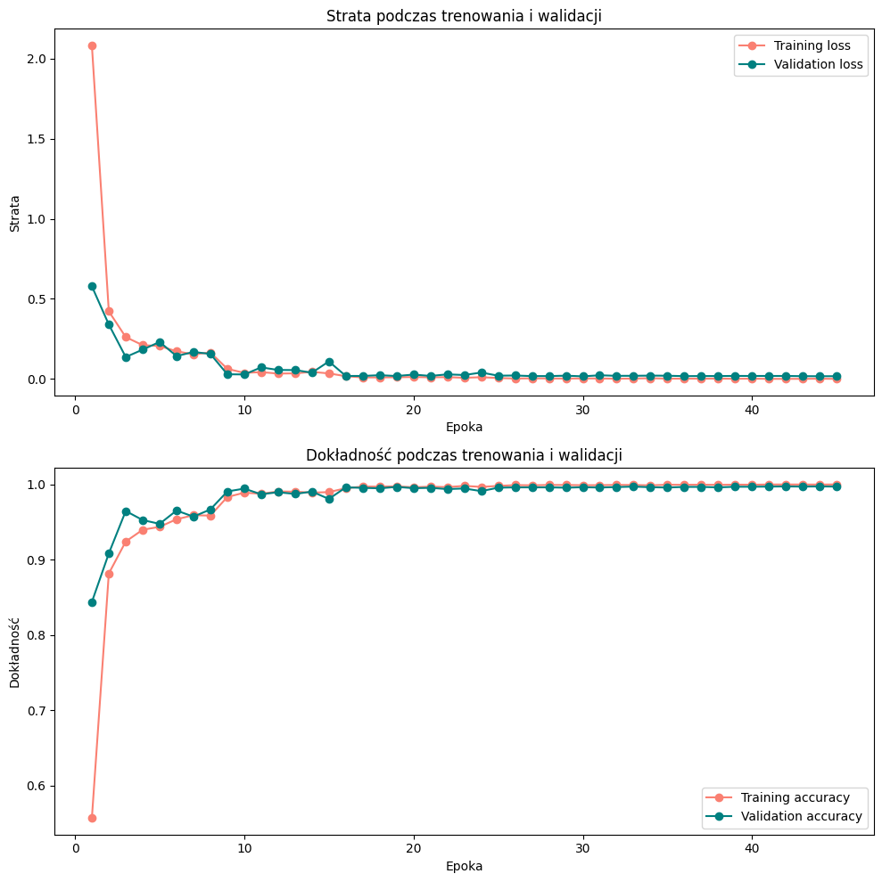

```python
acc = history.history['accuracy']
val_acc = history.history['val_accuracy']
loss = history.history['loss']
val_loss = history.history['val_loss']

epochs = range(1, len(acc) + 1)


plt.figure(figsize=(10, 10))

plt.subplot(2, 1, 1)
plt.plot(epochs, loss, 'o-', label='Training loss', color='salmon')
plt.plot(epochs, val_loss, 'o-', label='Validation loss', color='teal')
plt.title('Strata podczas trenowania i walidacji')
plt.xlabel('Epoka')
plt.ylabel('Strata')
plt.legend()


plt.subplot(2, 1, 2)
plt.plot(epochs, acc, 'o-', label='Training accuracy', color='salmon')
plt.plot(epochs, val_acc, 'o-', label='Validation accuracy', color='teal')
plt.title('Dokładność podczas trenowania i walidacji')
plt.xlabel('Epoka')
plt.ylabel('Dokładność')
plt.legend()

plt.tight_layout()
plt.show()
```

Wykresy nie wskazują na overfitting ani underfitting modelu – krzywe pokrywają się i mają dynamikę charakterystyczną dla dobrze dopasowanego modelu. Wartości na pierwszym wykresie spadają, osiągając niemal zerową stratę, natomiast krzywe na drugim wykresie rosną w miarę trwania treningu, osiągając prawie 100% dokładności.

```python
y_pred = model.predict(X_test)
y_pred_classes = np.argmax(y_pred, axis=1)
y_test_classes = np.argmax(y_test, axis=1)
```

```
191/191 ━━━━━━━━━━━━━━━━━━━━ 0s 2ms/step
```

```python
accuracy = accuracy_score(y_pred_classes, y_test_classes)
balanced_accuracy = balanced_accuracy_score(y_pred_classes, y_test_classes)
f1 = f1_score(y_pred_classes, y_test_classes, average='macro')
```

```python
print(f"Accuracy: {accuracy:.4f}")
print(f"Balanced Accuracy: {balanced_accuracy:.4f}")
print(f"F1 Score (Macro): {f1:.4f}")
```

```
Accuracy: 0.9962
Balanced Accuracy: 0.9963
F1 Score (Macro): 0.9962
```

Wartości wszystkich metryk są świetne – każda z nich wynosi około 0.996. Model dobrze radzi sobie z niewielką nierównowagą klas, ale tak jak wcześniej wspomniałem, była ona na tyle mała, że przypuszczałem, iż nie wpłynie znacząco na jakość modelu.

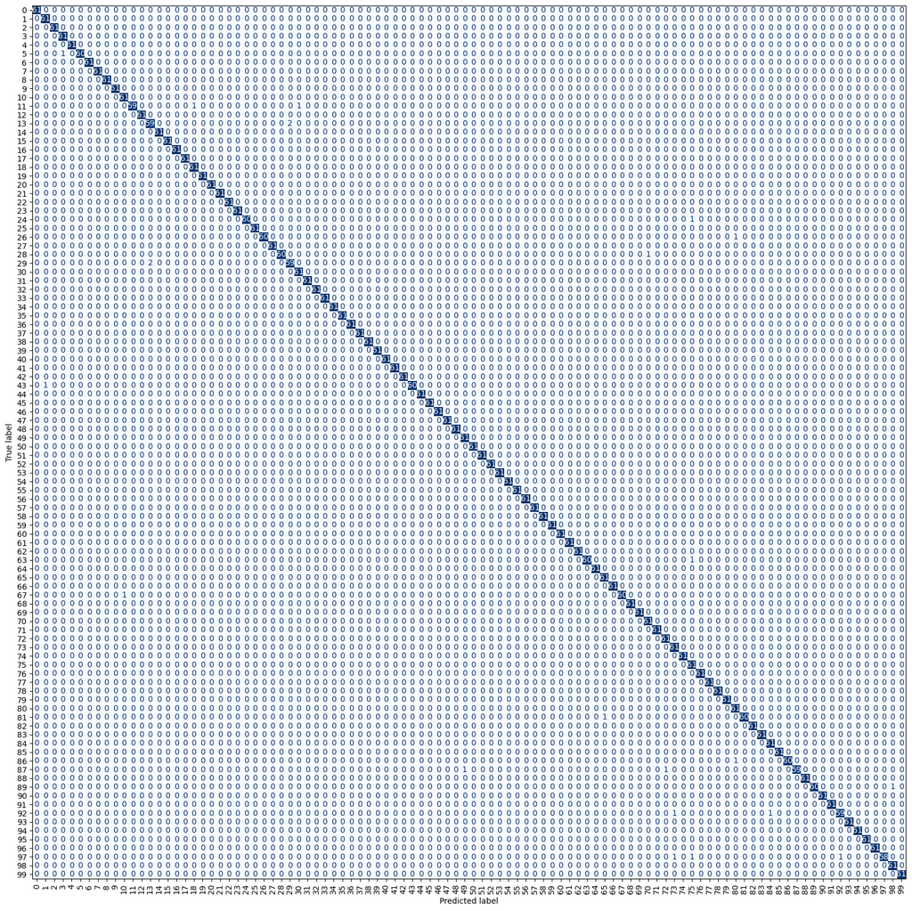

```python
cm = confusion_matrix(y_true=y_test_classes, y_pred=y_pred_classes)

# Ustawienie rozmiaru figury
fig, ax = plt.subplots(figsize=(20, 20))

# Wyświetlanie macierzy pomyłek bez paska kolorów
disp = ConfusionMatrixDisplay(confusion_matrix=cm)
disp.plot(cmap='Blues', ax=ax, colorbar=False)  # Wyłączenie color bar

# Obrót etykiet na osi X o 90 stopni
plt.xticks(rotation=90)

plt.show()
```

Z macierzy możemy odczytać, która z osób została błędnie zakwalifikowana i jako kto, np. osoba z ID 87 została zakwalifikowana jako osoba z ID 49. Nie widać jednak żadnych wzorców, co wynika z faktu, że model prawidłowo zaklasyfikował prawie 100% nagrań.

##### Model z mniejszą liczbą filtrów w warstwach konwolucyjnych.

Spróbujemy użyć mniejszej liczby filtrów w warstwach konwolucyjnych; może taka zmiana nie wpłynie znacząco na jakość modelu.

```python
# Ustawienie ziarna losowości dla powtarzalnych wyników
np.random.seed(11)
tf.random.set_seed(11)
np.random.seed(11)

# Inicjalizacja modelu
model2 = models.Sequential()


# Dodanie warstwy wejściowej z kształtem zgodnym z danymi MFCC (157, 13, 1)
model2.add(layers.Input(shape=(157, 13, 1)))


# Pierwsza warstwa konwolucyjna, która ma 64 filtry, okno o rozmiarze 3x3, ReLU jako funkcję aktywacji oraz padding 'same'
model2.add(layers.Conv2D(16, (3, 3), activation='relu', padding='same'))
# Normalizacja wsadowa dla lepszego uczenia
model2.add(layers.BatchNormalization())
# Max Pooling dla zmniejszenia rozmiaru przestrzennego o współczynnik 2
model2.add(layers.MaxPooling2D((2, 2)))
# Dropout dla zapobiegania przeuczeniu (wyłącza 10% neuronów losowo)
model2.add(layers.Dropout(0.1))


# Druga warstwa konwolucyjna, zwiększamy liczbę filtrów do 128
model2.add(layers.Conv2D(32, (3, 3), activation='relu', padding='same'))
model2.add(layers.BatchNormalization())
model2.add(layers.MaxPooling2D((2, 2)))
model2.add(layers.Dropout(0.1))


# Trzecia warstwa konwolucyjna, zwiększamy liczbę filtrów do 256
model2.add(layers.Conv2D(64, (3, 3), activation='relu', padding='same'))
model2.add(layers.BatchNormalization())
model2.add(layers.MaxPooling2D((2, 2)))
model2.add(layers.Dropout(0.1))


# Czwarta warstwa konwolucyjna, zwiększamy liczbę filtrów do 512
model2.add(layers.Conv2D(128, (3, 3), activation='relu', padding='same'))
model2.add(layers.BatchNormalization())
# Dropout dla zapobiegania przeuczeniu (tym razem wyłącza 20% neuronów)
model2.add(layers.Dropout(0.2))


# Spłaszczenie wyniku do wektora jednowymiarowego przed przekazaniem go do warstw w pełni połączonych
model2.add(layers.Flatten())


# Pierwsza warstwa w pełni połączona (Dense) z 2048 jednostkami, funkcja aktywacji ReLU
model2.add(layers.Dense(2048, activation='relu'))
model2.add(layers.BatchNormalization())
# Dropout dla zapobiegania przeuczeniu (wyłącza 75% neuronów)
model2.add(layers.Dropout(0.75))


# Warstwa wyjściowa - klasyfikacja wieloklasowa z 100 jednostkami i aktywacją softmax (klasyfikacja wieloklasowa)
model2.add(layers.Dense(100, activation='softmax'))  # 100 klas (każda klasa reprezentuje innego mówcę)


# Kompilacja modelu - optymalizator Adam, funkcja straty categorical_crossentropy (wieloklasowa klasyfikacja), oraz miara skuteczności - accuracy
model2.compile(optimizer='adam',
              loss='categorical_crossentropy',
              metrics=['accuracy'])


# Wyświetlenie podsumowania modelu
model2.summary()


# Callbacks: redukcja współczynnika uczenia (learning rate), gdy val_loss przestaje się poprawiać
reduce_lr = ReduceLROnPlateau(monitor='val_loss', factor=0.5, patience=5, min_lr=1e-8)
# Wczesne zatrzymanie treningu, jeśli val_loss nie poprawia się przez 10 epok, przywracając najlepsze wagi
early_stopping = EarlyStopping(monitor='val_loss', patience=15, restore_best_weights=True)


# Trenowanie modelu
history2 = model2.fit(
    X_train,    # Dane MFCC
    y_train,    # Etykiety one-hot encoded (macierz klas mówców)
    epochs=500,  # Liczba epok treningu
    batch_size=32,  # Rozmiar batcha (z dotychczasowych testów wynika, że 32 jest optymalne)
    validation_data=(X_valid, y_valid),  # Walidacja na wcześniej zdefiniowanych danych walidacyjnych
    callbacks=[reduce_lr, early_stopping]  # Callbacki do dynamicznej regulacji uczenia i wczesnego zatrzymania
)
```

```
Model: "sequential_4"
```

```
┏━━━━━━━━━━━━━━━━━━━━━━━━━━━━━━━━━┳━━━━━━━━━━━━━━━━━━━━━━━━┳━━━━━━━━━━━━━━━┓
┃ Layer (type)                    ┃ Output Shape           ┃       Param # ┃
┡━━━━━━━━━━━━━━━━━━━━━━━━━━━━━━━━━╇━━━━━━━━━━━━━━━━━━━━━━━━╇━━━━━━━━━━━━━━━┩
│ conv2d_16 (Conv2D)              │ (None, 157, 13, 16)    │           160 │
├─────────────────────────────────┼────────────────────────┼───────────────┤
│ batch_normalization_20          │ (None, 157, 13, 16)    │            64 │
│ (BatchNormalization)            │                        │               │
├─────────────────────────────────┼────────────────────────┼───────────────┤
│ max_pooling2d_12 (MaxPooling2D) │ (None, 78, 6, 16)      │             0 │
├─────────────────────────────────┼────────────────────────┼───────────────┤
│ dropout_20 (Dropout)            │ (None, 78, 6, 16)      │             0 │
├─────────────────────────────────┼────────────────────────┼───────────────┤
│ conv2d_17 (Conv2D)              │ (None, 78, 6, 32)      │         4,640 │
├─────────────────────────────────┼────────────────────────┼───────────────┤
│ batch_normalization_21          │ (None, 78, 6, 32)      │           128 │
│ (BatchNormalization)            │                        │               │
├─────────────────────────────────┼────────────────────────┼───────────────┤
│ max_pooling2d_13 (MaxPooling2D) │ (None, 39, 3, 32)      │             0 │
├─────────────────────────────────┼────────────────────────┼───────────────┤
│ dropout_21 (Dropout)            │ (None, 39, 3, 32)      │             0 │
├─────────────────────────────────┼────────────────────────┼───────────────┤
│ conv2d_18 (Conv2D)              │ (None, 39, 3, 64)      │        18,496 │
├─────────────────────────────────┼────────────────────────┼───────────────┤
│ batch_normalization_22          │ (None, 39, 3, 64)      │           256 │
│ (BatchNormalization)            │                        │               │
├─────────────────────────────────┼────────────────────────┼───────────────┤
│ max_pooling2d_14 (MaxPooling2D) │ (None, 19, 1, 64)      │             0 │
├─────────────────────────────────┼────────────────────────┼───────────────┤
│ dropout_22 (Dropout)            │ (None, 19, 1, 64)      │             0 │
├─────────────────────────────────┼────────────────────────┼───────────────┤
│ conv2d_19 (Conv2D)              │ (None, 19, 1, 128)     │        73,856 │
├─────────────────────────────────┼────────────────────────┼───────────────┤
│ batch_normalization_23          │ (None, 19, 1, 128)     │           512 │
│ (BatchNormalization)            │                        │               │
├─────────────────────────────────┼────────────────────────┼───────────────┤
│ dropout_23 (Dropout)            │ (None, 19, 1, 128)     │             0 │
├─────────────────────────────────┼────────────────────────┼───────────────┤
│ flatten_4 (Flatten)             │ (None, 2432)           │             0 │
├─────────────────────────────────┼────────────────────────┼───────────────┤
│ dense_8 (Dense)                 │ (None, 2048)           │     4,982,784 │
├─────────────────────────────────┼────────────────────────┼───────────────┤
│ batch_normalization_24          │ (None, 2048)           │         8,192 │
│ (BatchNormalization)            │                        │               │
├─────────────────────────────────┼────────────────────────┼───────────────┤
│ dropout_24 (Dropout)            │ (None, 2048)           │             0 │
├─────────────────────────────────┼────────────────────────┼───────────────┤
│ dense_9 (Dense)                 │ (None, 100)            │       204,900 │
└─────────────────────────────────┴────────────────────────┴───────────────┘
```

```
 Total params: 5,293,988 (20.19 MB)
```

```
 Trainable params: 5,289,412 (20.18 MB)
```

```
 Non-trainable params: 4,576 (17.88 KB)
```

```
602/602 ━━━━━━━━━━━━━━━━━━━━ 28s 26ms/step - accuracy: 0.1934 - loss: 4.7029 - val_accuracy: 0.7612 - val_loss: 0.8205 - learning_rate: 0.0010
602/602 ━━━━━━━━━━━━━━━━━━━━ 3s 5ms/step - accuracy: 0.7300 - loss: 0.9788 - val_accuracy: 0.9231 - val_loss: 0.2437 - learning_rate: 0.0010
602/602 ━━━━━━━━━━━━━━━━━━━━ 3s 5ms/step - accuracy: 0.8421 - loss: 0.5723 - val_accuracy: 0.9065 - val_loss: 0.3338 - learning_rate: 0.0010
602/602 ━━━━━━━━━━━━━━━━━━━━ 3s 5ms/step - accuracy: 0.8755 - loss: 0.4497 - val_accuracy: 0.9536 - val_loss: 0.1851 - learning_rate: 0.0010
602/602 ━━━━━━━━━━━━━━━━━━━━ 3s 5ms/step - accuracy: 0.9047 - loss: 0.3296 - val_accuracy: 0.9366 - val_loss: 0.2326 - learning_rate: 0.0010
602/602 ━━━━━━━━━━━━━━━━━━━━ 3s 5ms/step - accuracy: 0.9132 - loss: 0.3241 - val_accuracy: 0.9607 - val_loss: 0.1459 - learning_rate: 0.0010
602/602 ━━━━━━━━━━━━━━━━━━━━ 3s 5ms/step - accuracy: 0.9237 - loss: 0.2818 - val_accuracy: 0.9620 - val_loss: 0.1489 - learning_rate: 0.0010
602/602 ━━━━━━━━━━━━━━━━━━━━ 3s 5ms/step - accuracy: 0.9263 - loss: 0.2725 - val_accuracy: 0.9576 - val_loss: 0.1687 - learning_rate: 0.0010
602/602 ━━━━━━━━━━━━━━━━━━━━ 3s 5ms/step - accuracy: 0.9347 - loss: 0.2556 - val_accuracy: 0.9674 - val_loss: 0.1457 - learning_rate: 0.0010
602/602 ━━━━━━━━━━━━━━━━━━━━ 3s 5ms/step - accuracy: 0.9429 - loss: 0.2211 - val_accuracy: 0.9588 - val_loss: 0.1859 - learning_rate: 0.0010
602/602 ━━━━━━━━━━━━━━━━━━━━ 3s 5ms/step - accuracy: 0.9504 - loss: 0.2020 - val_accuracy: 0.9697 - val_loss: 0.1261 - learning_rate: 0.0010
602/602 ━━━━━━━━━━━━━━━━━━━━ 3s 5ms/step - accuracy: 0.9542 - loss: 0.1862 - val_accuracy: 0.9576 - val_loss: 0.1843 - learning_rate: 0.0010
602/602 ━━━━━━━━━━━━━━━━━━━━ 3s 5ms/step - accuracy: 0.9475 - loss: 0.2151 - val_accuracy: 0.9786 - val_loss: 0.0936 - learning_rate: 0.0010
602/602 ━━━━━━━━━━━━━━━━━━━━ 3s 5ms/step - accuracy: 0.9571 - loss: 0.1815 - val_accuracy: 0.9701 - val_loss: 0.1484 - learning_rate: 0.0010
602/602 ━━━━━━━━━━━━━━━━━━━━ 3s 5ms/step - accuracy: 0.9610 - loss: 0.1589 - val_accuracy: 0.9809 - val_loss: 0.0890 - learning_rate: 0.0010
602/602 ━━━━━━━━━━━━━━━━━━━━ 3s 5ms/step - accuracy: 0.9630 - loss: 0.1539 - val_accuracy: 0.9836 - val_loss: 0.0805 - learning_rate: 0.0010
602/602 ━━━━━━━━━━━━━━━━━━━━ 3s 5ms/step - accuracy: 0.9624 - loss: 0.1511 - val_accuracy: 0.9767 - val_loss: 0.1104 - learning_rate: 0.0010
602/602 ━━━━━━━━━━━━━━━━━━━━ 3s 5ms/step - accuracy: 0.9625 - loss: 0.1578 - val_accuracy: 0.9803 - val_loss: 0.1125 - learning_rate: 0.0010
602/602 ━━━━━━━━━━━━━━━━━━━━ 3s 5ms/step - accuracy: 0.9629 - loss: 0.1580 - val_accuracy: 0.9825 - val_loss: 0.0788 - learning_rate: 0.0010
602/602 ━━━━━━━━━━━━━━━━━━━━ 3s 5ms/step - accuracy: 0.9654 - loss: 0.1475 - val_accuracy: 0.9871 - val_loss: 0.0693 - learning_rate: 0.0010
602/602 ━━━━━━━━━━━━━━━━━━━━ 3s 5ms/step - accuracy: 0.9709 - loss: 0.1302 - val_accuracy: 0.9861 - val_loss: 0.0803 - learning_rate: 0.0010
602/602 ━━━━━━━━━━━━━━━━━━━━ 3s 5ms/step - accuracy: 0.9711 - loss: 0.1254 - val_accuracy: 0.9842 - val_loss: 0.0972 - learning_rate: 0.0010
602/602 ━━━━━━━━━━━━━━━━━━━━ 3s 5ms/step - accuracy: 0.9727 - loss: 0.1199 - val_accuracy: 0.9861 - val_loss: 0.0819 - learning_rate: 0.0010
602/602 ━━━━━━━━━━━━━━━━━━━━ 3s 5ms/step - accuracy: 0.9720 - loss: 0.1224 - val_accuracy: 0.9821 - val_loss: 0.1143 - learning_rate: 0.0010
602/602 ━━━━━━━━━━━━━━━━━━━━ 3s 5ms/step - accuracy: 0.9719 - loss: 0.1319 - val_accuracy: 0.9798 - val_loss: 0.1241 - learning_rate: 0.0010
602/602 ━━━━━━━━━━━━━━━━━━━━ 3s 5ms/step - accuracy: 0.9809 - loss: 0.0914 - val_accuracy: 0.9906 - val_loss: 0.0506 - learning_rate: 5.0000e-04
602/602 ━━━━━━━━━━━━━━━━━━━━ 3s 5ms/step - accuracy: 0.9871 - loss: 0.0536 - val_accuracy: 0.9904 - val_loss: 0.0531 - learning_rate: 5.0000e-04
602/602 ━━━━━━━━━━━━━━━━━━━━ 3s 5ms/step - accuracy: 0.9896 - loss: 0.0363 - val_accuracy: 0.9915 - val_loss: 0.0431 - learning_rate: 5.0000e-04
602/602 ━━━━━━━━━━━━━━━━━━━━ 3s 5ms/step - accuracy: 0.9885 - loss: 0.0482 - val_accuracy: 0.9913 - val_loss: 0.0525 - learning_rate: 5.0000e-04
602/602 ━━━━━━━━━━━━━━━━━━━━ 3s 5ms/step - accuracy: 0.9875 - loss: 0.0471 - val_accuracy: 0.9904 - val_loss: 0.0562 - learning_rate: 5.0000e-04
602/602 ━━━━━━━━━━━━━━━━━━━━ 3s 5ms/step - accuracy: 0.9929 - loss: 0.0281 - val_accuracy: 0.9879 - val_loss: 0.0763 - learning_rate: 5.0000e-04
602/602 ━━━━━━━━━━━━━━━━━━━━ 3s 5ms/step - accuracy: 0.9904 - loss: 0.0457 - val_accuracy: 0.9882 - val_loss: 0.0680 - learning_rate: 5.0000e-04
602/602 ━━━━━━━━━━━━━━━━━━━━ 3s 5ms/step - accuracy: 0.9922 - loss: 0.0319 - val_accuracy: 0.9898 - val_loss: 0.0628 - learning_rate: 5.0000e-04
602/602 ━━━━━━━━━━━━━━━━━━━━ 3s 5ms/step - accuracy: 0.9917 - loss: 0.0299 - val_accuracy: 0.9919 - val_loss: 0.0481 - learning_rate: 2.5000e-04
```

[output cut: 18 more lines]

Widzimy, że jakość modelu z mniejszą liczbą filtrów w warstwie konwolucyjnej jest nieco gorsza, ale nadal bardzo dobra – dokładność na zbiorze walidacyjnym wynosi ponad 99%.

```python
model2.save("model2.h5")
```

```python
model2 = load_model("model2.h5")
```

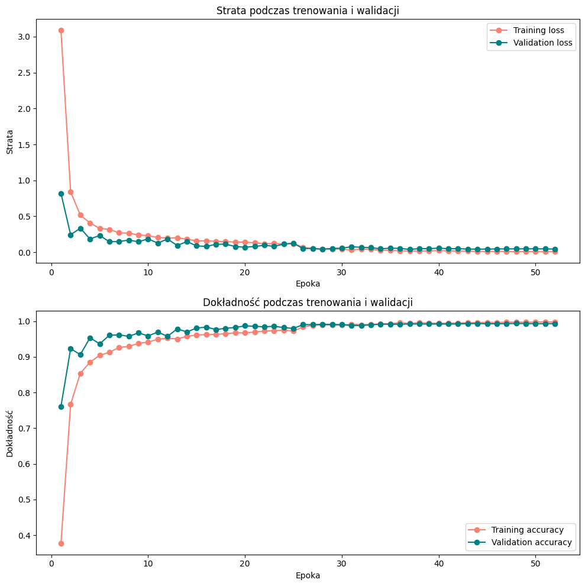

```python
acc = history2.history['accuracy']
val_acc = history2.history['val_accuracy']
loss = history2.history['loss']
val_loss = history2.history['val_loss']

epochs = range(1, len(acc) + 1)


plt.figure(figsize=(10, 10))

plt.subplot(2, 1, 1)
plt.plot(epochs, loss, 'o-', label='Training loss', color='salmon')
plt.plot(epochs, val_loss, 'o-', label='Validation loss', color='teal')
plt.title('Strata podczas trenowania i walidacji')
plt.xlabel('Epoka')
plt.ylabel('Strata')
plt.legend()


plt.subplot(2, 1, 2)
plt.plot(epochs, acc, 'o-', label='Training accuracy', color='salmon')
plt.plot(epochs, val_acc, 'o-', label='Validation accuracy', color='teal')
plt.title('Dokładność podczas trenowania i walidacji')
plt.xlabel('Epoka')
plt.ylabel('Dokładność')
plt.legend()

plt.tight_layout()
plt.show()
```

Dynamika wykresów wskazuje na dobrą jakość modelu. Nie widać również tendencji ani do overfittingu, ani do underfittingu.

```python
y_pred = model2.predict(X_test)
y_pred_classes = np.argmax(y_pred, axis=1)
y_test_classes = np.argmax(y_test, axis=1)
```

```
191/191 ━━━━━━━━━━━━━━━━━━━━ 1s 3ms/step
```

```python
accuracy = accuracy_score(y_pred_classes, y_test_classes)
balanced_accuracy = balanced_accuracy_score(y_pred_classes, y_test_classes)
f1 = f1_score(y_pred_classes, y_test_classes, average='macro')
```

```python
print(f"Accuracy: {accuracy:.4f}")
print(f"Balanced Accuracy: {balanced_accuracy:.4f}")
print(f"F1 Score (Macro): {f1:.4f}")
```

```
Accuracy: 0.9930
Balanced Accuracy: 0.9931
F1 Score (Macro): 0.9930
```

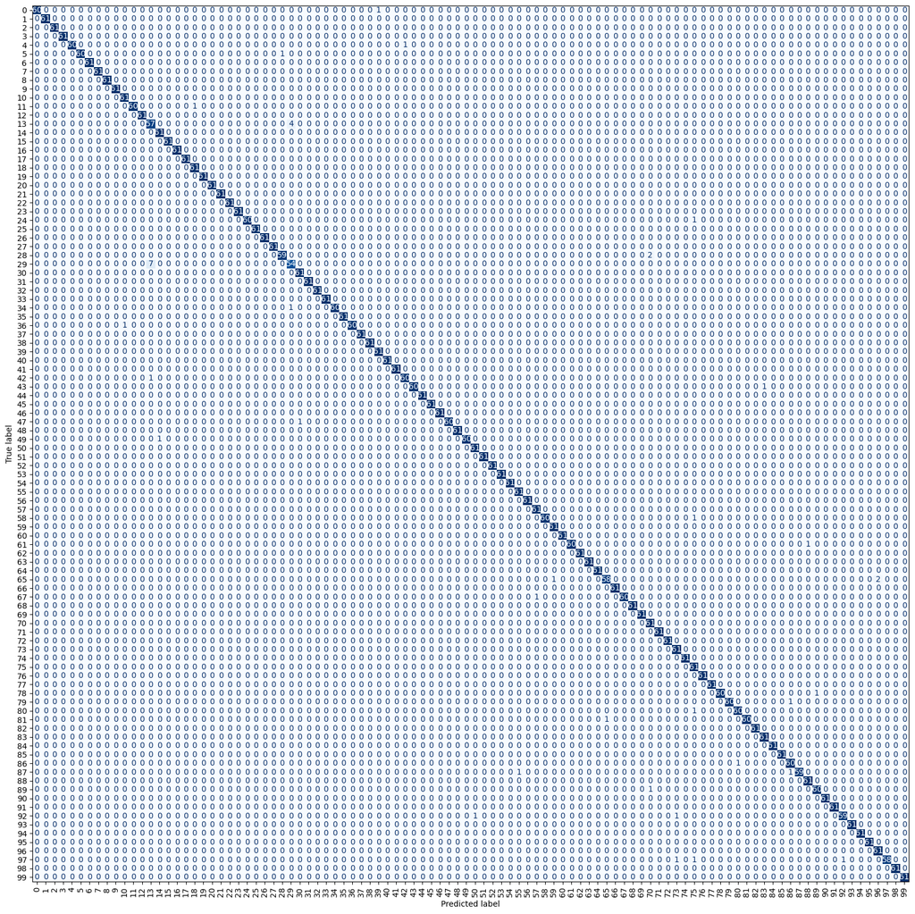

```python
cm = confusion_matrix(y_true=y_test_classes, y_pred=y_pred_classes)

# Ustawienie rozmiaru figury
fig, ax = plt.subplots(figsize=(20, 20))

# Wyświetlanie macierzy pomyłek bez paska kolorów
disp = ConfusionMatrixDisplay(confusion_matrix=cm)
disp.plot(cmap='Blues', ax=ax, colorbar=False)  # Wyłączenie color bar

# Obrót etykiet na osi X o 90 stopni
plt.xticks(rotation=90)

plt.show()
```

### Nagrania o długości 2 sekund.

Powtórzę powyższe eksperymenty – stworzę dwa modele: jeden z większą liczbą filtrów w warstwach konwolucyjnych, a drugi z mniejszą liczbą filtrów. Modele będą trenowane i testowane na nagraniach o długości 2 sekund. Nie będę tworzył macierzy pomyłek dla tych modeli, ponieważ wiem, że wypadną gorzej od poprzednich modeli, a nie chcę zbędnie wydłużać raportu.

```python
train_mfcc_list = []
test_mfcc_list = []

train_owner = []
test_owner = []

# W pętli korzystam z wcześniej zdefiniowanej funkcji, która dzieli nagrania każdej z 100 osób
# (50 mężczyzn i 50 kobiet) na zestaw treningowy i testowy.

for i in range(0, 100):

    # Wywołuję funkcję split_train_test_data, aby podzielić nagrania danej osoby na zbiory treningowe i testowe.
    train_mfcc, test_mfcc = split_train_test_data(top_50_man_and_woman[i], seconds = 2)

    # Dodaję uzyskane dane MFCC do odpowiednich list.
    train_mfcc_list.extend(train_mfcc)
    test_mfcc_list.extend(test_mfcc)

    # Do listy train_owner i test_owner dodaję identyfikatory osób (i) tyle razy, ile jest nagrań.
    train_owner.extend([i] * len(train_mfcc))
    test_owner.extend([i] * len(test_mfcc))

    # Wyświetlam numer osoby w pętli, aby śledzić postęp.
    print(i)
    clear_output(wait=True)

# Konwertuję listy train_mfcc_list i test_mfcc_list na tablice NumPy dla łatwiejszego przetwarzania w kolejnych krokach.
train_mfcc_list = np.array(train_mfcc_list)
test_mfcc_list = np.array(test_mfcc_list)

# Konwertuję listy train_owner i test_owner na tablice NumPy.
train_owner = np.array(train_owner)
test_owner = np.array(test_owner)
```

```
99
```

```python
# Łączenie wszystkich macierzy MFCC z zestawu treningowego w jedną dużą macierz.
# To posłuży do dopasowania skalera (normalizatora) do danych.
commmon_df_for_train = np.concatenate(train_mfcc_list, axis=0)

# Inicjalizuję skaler StandardScaler, który będzie normalizował dane (średnia = 0, odchylenie standardowe = 1).
scaler = StandardScaler()

# Dopasowanie skalera do połączonych danych treningowych (uzyskanie parametrów normalizacji).
scaler.fit(commmon_df_for_train)

# Normalizuję dane MFCC dla każdego fragmentu nagrania w zestawie treningowym.
X_train = [scaler.transform(one_audio) for one_audio in train_mfcc_list]

# Normalizuję dane MFCC dla każdego fragmentu nagrania w zestawie testowym.
X_test = [scaler.transform(one_audio) for one_audio in test_mfcc_list]

# Konwertuję znormalizowane dane treningowe i testowe na tablice NumPy w celu łatwiejszego przetwarzania.
X_train = np.array(X_train)
X_test = np.array(X_test)

# Ustalam rozmiar zestawu treningowego - 80% danych.
train_size = int(np.floor(len(X_train) * 0.8))

# Losowy wybór indeksów, które zostaną użyte jako dane treningowe (80% próbek).
index_of_train = np.random.choice(np.arange(0, len(X_train)), size=train_size, replace=False)

# Pozostałe indeksy są używane do walidacji (20% próbek).
index_of_valid = ~np.isin(np.arange(0, len(X_train)), index_of_train)

# Tworzę zbiór walidacyjny z X_train, wybierając próbki z indeksów przypisanych do walidacji.
X_valid = X_train[index_of_valid]

# Ostatecznie, X_train zawiera dane treningowe po wybraniu 80% próbek.
X_train = X_train[index_of_train]

# Przypisuję odpowiednie identyfikatory właścicieli (osób) do zbiorów walidacyjnych i treningowych.
valid_owner = train_owner[index_of_valid]
train_owner = train_owner[index_of_train]
```

```python
# Przekształcam dane treningowe (X_train), aby miały odpowiedni kształt dla sieci CNN.
# Dodaję nowy wymiar (1) na końcu, ponieważ sieci konwolucyjne oczekują wejść o formacie 4D:
# (liczba próbek, wysokość, szerokość, liczba kanałów). Tutaj mamy 1 kanał (monofoniczne nagrania).
X_train = X_train.reshape((X_train.shape[0],
                           X_train.shape[1],
                           X_train.shape[2],
                           1))

# Przekształcam dane walidacyjne (X_valid) do tego samego formatu 4D co dane treningowe.
X_valid = X_valid.reshape((X_valid.shape[0],
                           X_valid.shape[1],
                           X_valid.shape[2],
                           1))

# Przekształcam dane testowe (X_test) w podobny sposób, aby miały wymiar 4D odpowiedni dla sieci CNN.
X_test = X_test.reshape((X_test.shape[0],
                         X_test.shape[1],
                         X_test.shape[2],
                         1))

# Konwertuję etykiety dla zestawu treningowego (train_owner) na postać one-hot encoding dla klasyfikacji wieloklasowej (100 klas).
# Używam funkcji to_categorical, aby zamienić numeryczne etykiety (ID osób) na macierze o rozmiarze [100], gdzie
# każda wartość reprezentuje prawdopodobieństwo przynależności do danej klasy.
y_train = to_categorical(train_owner, num_classes=100)

# Podobnie konwertuję etykiety dla zestawu walidacyjnego na one-hot encoding.
y_valid = to_categorical(valid_owner, num_classes=100)

# Konwersja etykiet dla zestawu testowego na postać one-hot encoding (również 100 klas).
y_test = to_categorical(test_owner, num_classes=100)
```

```python
y_train_labels = np.argmax(y_train, axis=1)

class_counts = np.bincount(y_train_labels)

print(np.min(class_counts), np.max(class_counts))
```

```
460 508
```

```python
# Ustawienie ziarna losowości dla powtarzalnych wyników
np.random.seed(11)
tf.random.set_seed(11)
np.random.seed(11)

# Inicjalizacja modelu
model = models.Sequential()


# Dodanie warstwy wejściowej z kształtem zgodnym z danymi MFCC (157, 13, 1)
model.add(layers.Input(shape=(63, 13, 1)))


# Pierwsza warstwa konwolucyjna, która ma 64 filtry, okno o rozmiarze 3x3, ReLU jako funkcję aktywacji oraz padding 'same'
model.add(layers.Conv2D(64, (3, 3), activation='relu', padding='same'))
# Normalizacja wsadowa dla lepszego uczenia
model.add(layers.BatchNormalization())
# Max Pooling dla zmniejszenia rozmiaru przestrzennego o współczynnik 2
model.add(layers.MaxPooling2D((2, 2)))
# Dropout dla zapobiegania przeuczeniu (wyłącza 10% neuronów losowo)
model.add(layers.Dropout(0.1))


# Druga warstwa konwolucyjna, zwiększamy liczbę filtrów do 128
model.add(layers.Conv2D(128, (3, 3), activation='relu', padding='same'))
model.add(layers.BatchNormalization())
model.add(layers.MaxPooling2D((2, 2)))
model.add(layers.Dropout(0.1))


# Trzecia warstwa konwolucyjna, zwiększamy liczbę filtrów do 256
model.add(layers.Conv2D(256, (3, 3), activation='relu', padding='same'))
model.add(layers.BatchNormalization())
model.add(layers.MaxPooling2D((2, 2)))
model.add(layers.Dropout(0.1))


# Czwarta warstwa konwolucyjna, zwiększamy liczbę filtrów do 512
model.add(layers.Conv2D(512, (3, 3), activation='relu', padding='same'))
model.add(layers.BatchNormalization())
# Dropout dla zapobiegania przeuczeniu (tym razem wyłącza 20% neuronów)
model.add(layers.Dropout(0.2))


# Spłaszczenie wyniku do wektora jednowymiarowego przed przekazaniem go do warstw w pełni połączonych
model.add(layers.Flatten())


# Pierwsza warstwa w pełni połączona (Dense) z 2048 jednostkami, funkcja aktywacji ReLU
model.add(layers.Dense(2048, activation='relu'))
model.add(layers.BatchNormalization())
# Dropout dla zapobiegania przeuczeniu (wyłącza 75% neuronów)
model.add(layers.Dropout(0.75))


# Warstwa wyjściowa - klasyfikacja wieloklasowa z 100 jednostkami i aktywacją softmax (klasyfikacja wieloklasowa)
model.add(layers.Dense(100, activation='softmax'))  # 100 klas (każda klasa reprezentuje innego mówcę)


# Kompilacja modelu - optymalizator Adam, funkcja straty categorical_crossentropy (wieloklasowa klasyfikacja), oraz miara skuteczności - accuracy
model.compile(optimizer='adam',
              loss='categorical_crossentropy',
              metrics=['accuracy'])


# Wyświetlenie podsumowania modelu
model.summary()


# Callbacks: redukcja współczynnika uczenia (learning rate), gdy val_loss przestaje się poprawiać
reduce_lr = ReduceLROnPlateau(monitor='val_loss', factor=0.5, patience=5, min_lr=1e-8)
# Wczesne zatrzymanie treningu, jeśli val_loss nie poprawia się przez 10 epok, przywracając najlepsze wagi
early_stopping = EarlyStopping(monitor='val_loss', patience=15, restore_best_weights=True)


# Trenowanie modelu
history = model.fit(
    X_train,    # Dane MFCC
    y_train,    # Etykiety one-hot encoded (macierz klas mówców)
    epochs=500,  # Liczba epok treningu
    batch_size=32,  # Rozmiar batcha (z dotychczasowych testów wynika, że 32 jest optymalne)
    validation_data=(X_valid, y_valid),  # Walidacja na wcześniej zdefiniowanych danych walidacyjnych
    callbacks=[reduce_lr, early_stopping]  # Callbacki do dynamicznej regulacji uczenia i wczesnego zatrzymania
)
```

```
Model: "sequential"
```

```
┏━━━━━━━━━━━━━━━━━━━━━━━━━━━━━━━━━┳━━━━━━━━━━━━━━━━━━━━━━━━┳━━━━━━━━━━━━━━━┓
┃ Layer (type)                    ┃ Output Shape           ┃       Param # ┃
┡━━━━━━━━━━━━━━━━━━━━━━━━━━━━━━━━━╇━━━━━━━━━━━━━━━━━━━━━━━━╇━━━━━━━━━━━━━━━┩
│ conv2d (Conv2D)                 │ (None, 63, 13, 64)     │           640 │
├─────────────────────────────────┼────────────────────────┼───────────────┤
│ batch_normalization             │ (None, 63, 13, 64)     │           256 │
│ (BatchNormalization)            │                        │               │
├─────────────────────────────────┼────────────────────────┼───────────────┤
│ max_pooling2d (MaxPooling2D)    │ (None, 31, 6, 64)      │             0 │
├─────────────────────────────────┼────────────────────────┼───────────────┤
│ dropout (Dropout)               │ (None, 31, 6, 64)      │             0 │
├─────────────────────────────────┼────────────────────────┼───────────────┤
│ conv2d_1 (Conv2D)               │ (None, 31, 6, 128)     │        73,856 │
├─────────────────────────────────┼────────────────────────┼───────────────┤
│ batch_normalization_1           │ (None, 31, 6, 128)     │           512 │
│ (BatchNormalization)            │                        │               │
├─────────────────────────────────┼────────────────────────┼───────────────┤
│ max_pooling2d_1 (MaxPooling2D)  │ (None, 15, 3, 128)     │             0 │
├─────────────────────────────────┼────────────────────────┼───────────────┤
│ dropout_1 (Dropout)             │ (None, 15, 3, 128)     │             0 │
├─────────────────────────────────┼────────────────────────┼───────────────┤
│ conv2d_2 (Conv2D)               │ (None, 15, 3, 256)     │       295,168 │
├─────────────────────────────────┼────────────────────────┼───────────────┤
│ batch_normalization_2           │ (None, 15, 3, 256)     │         1,024 │
│ (BatchNormalization)            │                        │               │
├─────────────────────────────────┼────────────────────────┼───────────────┤
│ max_pooling2d_2 (MaxPooling2D)  │ (None, 7, 1, 256)      │             0 │
├─────────────────────────────────┼────────────────────────┼───────────────┤
│ dropout_2 (Dropout)             │ (None, 7, 1, 256)      │             0 │
├─────────────────────────────────┼────────────────────────┼───────────────┤
│ conv2d_3 (Conv2D)               │ (None, 7, 1, 512)      │     1,180,160 │
├─────────────────────────────────┼────────────────────────┼───────────────┤
│ batch_normalization_3           │ (None, 7, 1, 512)      │         2,048 │
│ (BatchNormalization)            │                        │               │
├─────────────────────────────────┼────────────────────────┼───────────────┤
│ dropout_3 (Dropout)             │ (None, 7, 1, 512)      │             0 │
├─────────────────────────────────┼────────────────────────┼───────────────┤
│ flatten (Flatten)               │ (None, 3584)           │             0 │
├─────────────────────────────────┼────────────────────────┼───────────────┤
│ dense (Dense)                   │ (None, 2048)           │     7,342,080 │
├─────────────────────────────────┼────────────────────────┼───────────────┤
│ batch_normalization_4           │ (None, 2048)           │         8,192 │
│ (BatchNormalization)            │                        │               │
├─────────────────────────────────┼────────────────────────┼───────────────┤
│ dropout_4 (Dropout)             │ (None, 2048)           │             0 │
├─────────────────────────────────┼────────────────────────┼───────────────┤
│ dense_1 (Dense)                 │ (None, 100)            │       204,900 │
└─────────────────────────────────┴────────────────────────┴───────────────┘
```

```
 Total params: 9,108,836 (34.75 MB)
```

```
 Trainable params: 9,102,820 (34.72 MB)
```

```
 Non-trainable params: 6,016 (23.50 KB)
```

[output not shown]

```
  27/1509 ━━━━━━━━━━━━━━━━━━━━ 8s 6ms/step - accuracy: 0.0150 - loss: 7.5341
```

```
I0000 00:00:1729948302.580173     114 device_compiler.h:188] Compiled cluster using XLA!  This line is logged at most once for the lifetime of the process.
```

```
1509/1509 ━━━━━━━━━━━━━━━━━━━━ 34s 14ms/step - accuracy: 0.3353 - loss: 3.6236 - val_accuracy: 0.8406 - val_loss: 0.6229 - learning_rate: 0.0010
1509/1509 ━━━━━━━━━━━━━━━━━━━━ 9s 6ms/step - accuracy: 0.7876 - loss: 0.8349 - val_accuracy: 0.8992 - val_loss: 0.3918 - learning_rate: 0.0010
1509/1509 ━━━━━━━━━━━━━━━━━━━━ 9s 6ms/step - accuracy: 0.8483 - loss: 0.6030 - val_accuracy: 0.9353 - val_loss: 0.2546 - learning_rate: 0.0010
1509/1509 ━━━━━━━━━━━━━━━━━━━━ 9s 6ms/step - accuracy: 0.8809 - loss: 0.4794 - val_accuracy: 0.9291 - val_loss: 0.3045 - learning_rate: 0.0010
1509/1509 ━━━━━━━━━━━━━━━━━━━━ 9s 6ms/step - accuracy: 0.9001 - loss: 0.4126 - val_accuracy: 0.9315 - val_loss: 0.3265 - learning_rate: 0.0010
1509/1509 ━━━━━━━━━━━━━━━━━━━━ 9s 6ms/step - accuracy: 0.9174 - loss: 0.3417 - val_accuracy: 0.9552 - val_loss: 0.2051 - learning_rate: 0.0010
1509/1509 ━━━━━━━━━━━━━━━━━━━━ 9s 6ms/step - accuracy: 0.9312 - loss: 0.2833 - val_accuracy: 0.9538 - val_loss: 0.2100 - learning_rate: 0.0010
1509/1509 ━━━━━━━━━━━━━━━━━━━━ 9s 6ms/step - accuracy: 0.9433 - loss: 0.2360 - val_accuracy: 0.9672 - val_loss: 0.1466 - learning_rate: 0.0010
1509/1509 ━━━━━━━━━━━━━━━━━━━━ 9s 6ms/step - accuracy: 0.9484 - loss: 0.2047 - val_accuracy: 0.9664 - val_loss: 0.1487 - learning_rate: 0.0010
1509/1509 ━━━━━━━━━━━━━━━━━━━━ 9s 6ms/step - accuracy: 0.9516 - loss: 0.1985 - val_accuracy: 0.9674 - val_loss: 0.1622 - learning_rate: 0.0010
1509/1509 ━━━━━━━━━━━━━━━━━━━━ 9s 6ms/step - accuracy: 0.9561 - loss: 0.1854 - val_accuracy: 0.9718 - val_loss: 0.1318 - learning_rate: 0.0010
1509/1509 ━━━━━━━━━━━━━━━━━━━━ 9s 6ms/step - accuracy: 0.9633 - loss: 0.1452 - val_accuracy: 0.9694 - val_loss: 0.1680 - learning_rate: 0.0010
1509/1509 ━━━━━━━━━━━━━━━━━━━━ 9s 6ms/step - accuracy: 0.9675 - loss: 0.1330 - val_accuracy: 0.9712 - val_loss: 0.1575 - learning_rate: 0.0010
1509/1509 ━━━━━━━━━━━━━━━━━━━━ 9s 6ms/step - accuracy: 0.9657 - loss: 0.1508 - val_accuracy: 0.9750 - val_loss: 0.1213 - learning_rate: 0.0010
1509/1509 ━━━━━━━━━━━━━━━━━━━━ 9s 6ms/step - accuracy: 0.9715 - loss: 0.1136 - val_accuracy: 0.9760 - val_loss: 0.1227 - learning_rate: 0.0010
1509/1509 ━━━━━━━━━━━━━━━━━━━━ 9s 6ms/step - accuracy: 0.9725 - loss: 0.1104 - val_accuracy: 0.9753 - val_loss: 0.1272 - learning_rate: 0.0010
1509/1509 ━━━━━━━━━━━━━━━━━━━━ 9s 6ms/step - accuracy: 0.9734 - loss: 0.1021 - val_accuracy: 0.9797 - val_loss: 0.1045 - learning_rate: 0.0010
1509/1509 ━━━━━━━━━━━━━━━━━━━━ 9s 6ms/step - accuracy: 0.9773 - loss: 0.0900 - val_accuracy: 0.9772 - val_loss: 0.1249 - learning_rate: 0.0010
1509/1509 ━━━━━━━━━━━━━━━━━━━━ 9s 6ms/step - accuracy: 0.9766 - loss: 0.0987 - val_accuracy: 0.9737 - val_loss: 0.1627 - learning_rate: 0.0010
1509/1509 ━━━━━━━━━━━━━━━━━━━━ 9s 6ms/step - accuracy: 0.9788 - loss: 0.0828 - val_accuracy: 0.9805 - val_loss: 0.0945 - learning_rate: 0.0010
1509/1509 ━━━━━━━━━━━━━━━━━━━━ 9s 6ms/step - accuracy: 0.9804 - loss: 0.0807 - val_accuracy: 0.9767 - val_loss: 0.1327 - learning_rate: 0.0010
1509/1509 ━━━━━━━━━━━━━━━━━━━━ 9s 6ms/step - accuracy: 0.9817 - loss: 0.0764 - val_accuracy: 0.9768 - val_loss: 0.1256 - learning_rate: 0.0010
1509/1509 ━━━━━━━━━━━━━━━━━━━━ 9s 6ms/step - accuracy: 0.9814 - loss: 0.0700 - val_accuracy: 0.9800 - val_loss: 0.1183 - learning_rate: 0.0010
1509/1509 ━━━━━━━━━━━━━━━━━━━━ 9s 6ms/step - accuracy: 0.9829 - loss: 0.0725 - val_accuracy: 0.9804 - val_loss: 0.1112 - learning_rate: 0.0010
1509/1509 ━━━━━━━━━━━━━━━━━━━━ 9s 6ms/step - accuracy: 0.9812 - loss: 0.0739 - val_accuracy: 0.9811 - val_loss: 0.1052 - learning_rate: 0.0010
1509/1509 ━━━━━━━━━━━━━━━━━━━━ 9s 6ms/step - accuracy: 0.9878 - loss: 0.0458 - val_accuracy: 0.9856 - val_loss: 0.0805 - learning_rate: 5.0000e-04
1509/1509 ━━━━━━━━━━━━━━━━━━━━ 9s 6ms/step - accuracy: 0.9931 - loss: 0.0261 - val_accuracy: 0.9858 - val_loss: 0.0792 - learning_rate: 5.0000e-04
1509/1509 ━━━━━━━━━━━━━━━━━━━━ 9s 6ms/step - accuracy: 0.9923 - loss: 0.0278 - val_accuracy: 0.9851 - val_loss: 0.0828 - learning_rate: 5.0000e-04
1509/1509 ━━━━━━━━━━━━━━━━━━━━ 9s 6ms/step - accuracy: 0.9931 - loss: 0.0234 - val_accuracy: 0.9862 - val_loss: 0.0776 - learning_rate: 5.0000e-04
1509/1509 ━━━━━━━━━━━━━━━━━━━━ 9s 6ms/step - accuracy: 0.9938 - loss: 0.0230 - val_accuracy: 0.9853 - val_loss: 0.0864 - learning_rate: 5.0000e-04
1509/1509 ━━━━━━━━━━━━━━━━━━━━ 9s 6ms/step - accuracy: 0.9935 - loss: 0.0211 - val_accuracy: 0.9856 - val_loss: 0.0793 - learning_rate: 5.0000e-04
1509/1509 ━━━━━━━━━━━━━━━━━━━━ 9s 6ms/step - accuracy: 0.9943 - loss: 0.0200 - val_accuracy: 0.9856 - val_loss: 0.0819 - learning_rate: 5.0000e-04
1509/1509 ━━━━━━━━━━━━━━━━━━━━ 9s 6ms/step - accuracy: 0.9940 - loss: 0.0226 - val_accuracy: 0.9868 - val_loss: 0.0735 - learning_rate: 5.0000e-04
1509/1509 ━━━━━━━━━━━━━━━━━━━━ 9s 6ms/step - accuracy: 0.9943 - loss: 0.0216 - val_accuracy: 0.9871 - val_loss: 0.0753 - learning_rate: 5.0000e-04
1509/1509 ━━━━━━━━━━━━━━━━━━━━ 9s 6ms/step - accuracy: 0.9949 - loss: 0.0168 - val_accuracy: 0.9853 - val_loss: 0.0756 - learning_rate: 5.0000e-04
1509/1509 ━━━━━━━━━━━━━━━━━━━━ 9s 6ms/step - accuracy: 0.9953 - loss: 0.0163 - val_accuracy: 0.9855 - val_loss: 0.0738 - learning_rate: 5.0000e-04
1509/1509 ━━━━━━━━━━━━━━━━━━━━ 9s 6ms/step - accuracy: 0.9945 - loss: 0.0212 - val_accuracy: 0.9872 - val_loss: 0.0674 - learning_rate: 5.0000e-04
1509/1509 ━━━━━━━━━━━━━━━━━━━━ 9s 6ms/step - accuracy: 0.9942 - loss: 0.0202 - val_accuracy: 0.9876 - val_loss: 0.0656 - learning_rate: 5.0000e-04
1509/1509 ━━━━━━━━━━━━━━━━━━━━ 9s 6ms/step - accuracy: 0.9963 - loss: 0.0140 - val_accuracy: 0.9869 - val_loss: 0.0698 - learning_rate: 5.0000e-04
1509/1509 ━━━━━━━━━━━━━━━━━━━━ 9s 6ms/step - accuracy: 0.9962 - loss: 0.0162 - val_accuracy: 0.9875 - val_loss: 0.0723 - learning_rate: 5.0000e-04
```

[output cut: 34 more lines]

```
1509/1509 ━━━━━━━━━━━━━━━━━━━━ 9s 6ms/step - accuracy: 0.9992 - loss: 0.0022 - val_accuracy: 0.9917 - val_loss: 0.0471 - learning_rate: 6.2500e-05
1509/1509 ━━━━━━━━━━━━━━━━━━━━ 9s 6ms/step - accuracy: 0.9996 - loss: 0.0013 - val_accuracy: 0.9919 - val_loss: 0.0462 - learning_rate: 6.2500e-05
1509/1509 ━━━━━━━━━━━━━━━━━━━━ 9s 6ms/step - accuracy: 0.9997 - loss: 9.9530e-04 - val_accuracy: 0.9917 - val_loss: 0.0485 - learning_rate: 6.2500e-05
1509/1509 ━━━━━━━━━━━━━━━━━━━━ 9s 6ms/step - accuracy: 0.9996 - loss: 9.3440e-04 - val_accuracy: 0.9915 - val_loss: 0.0502 - learning_rate: 6.2500e-05
1509/1509 ━━━━━━━━━━━━━━━━━━━━ 9s 6ms/step - accuracy: 0.9998 - loss: 5.3437e-04 - val_accuracy: 0.9917 - val_loss: 0.0470 - learning_rate: 6.2500e-05
1509/1509 ━━━━━━━━━━━━━━━━━━━━ 9s 6ms/step - accuracy: 0.9996 - loss: 0.0013 - val_accuracy: 0.9913 - val_loss: 0.0465 - learning_rate: 3.1250e-05
1509/1509 ━━━━━━━━━━━━━━━━━━━━ 9s 6ms/step - accuracy: 0.9997 - loss: 8.5619e-04 - val_accuracy: 0.9909 - val_loss: 0.0494 - learning_rate: 3.1250e-05
1509/1509 ━━━━━━━━━━━━━━━━━━━━ 9s 6ms/step - accuracy: 0.9997 - loss: 0.0012 - val_accuracy: 0.9912 - val_loss: 0.0491 - learning_rate: 3.1250e-05
1509/1509 ━━━━━━━━━━━━━━━━━━━━ 9s 6ms/step - accuracy: 0.9994 - loss: 0.0020 - val_accuracy: 0.9918 - val_loss: 0.0483 - learning_rate: 3.1250e-05
1509/1509 ━━━━━━━━━━━━━━━━━━━━ 9s 6ms/step - accuracy: 0.9997 - loss: 6.4848e-04 - val_accuracy: 0.9920 - val_loss: 0.0483 - learning_rate: 3.1250e-05
1509/1509 ━━━━━━━━━━━━━━━━━━━━ 9s 6ms/step - accuracy: 0.9998 - loss: 5.4988e-04 - val_accuracy: 0.9920 - val_loss: 0.0490 - learning_rate: 1.5625e-05
1509/1509 ━━━━━━━━━━━━━━━━━━━━ 9s 6ms/step - accuracy: 0.9996 - loss: 0.0011 - val_accuracy: 0.9918 - val_loss: 0.0484 - learning_rate: 1.5625e-05
1509/1509 ━━━━━━━━━━━━━━━━━━━━ 9s 6ms/step - accuracy: 0.9996 - loss: 0.0011 - val_accuracy: 0.9920 - val_loss: 0.0477 - learning_rate: 1.5625e-05
1509/1509 ━━━━━━━━━━━━━━━━━━━━ 9s 6ms/step - accuracy: 0.9998 - loss: 8.2051e-04 - val_accuracy: 0.9917 - val_loss: 0.0475 - learning_rate: 1.5625e-05
1509/1509 ━━━━━━━━━━━━━━━━━━━━ 9s 6ms/step - accuracy: 0.9996 - loss: 0.0012 - val_accuracy: 0.9920 - val_loss: 0.0482 - learning_rate: 1.5625e-05
```

Patrząc na dokładność na zbiorze walidacyjnym, widzimy, że model jest gorszy od poprzednich, które były trenowane na nagraniach o długości 5 sekund.

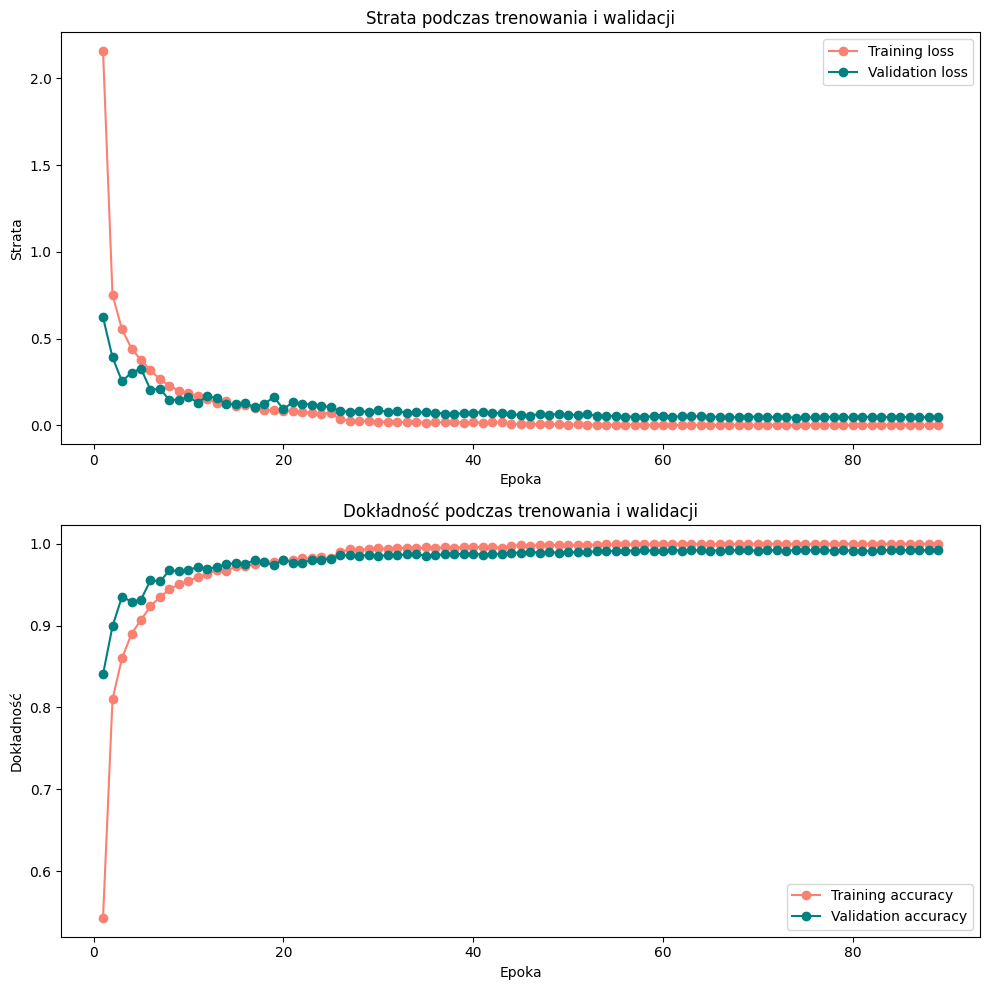

```python
acc = history.history['accuracy']
val_acc = history.history['val_accuracy']
loss = history.history['loss']
val_loss = history.history['val_loss']

epochs = range(1, len(acc) + 1)


plt.figure(figsize=(10, 10))

plt.subplot(2, 1, 1)
plt.plot(epochs, loss, 'o-', label='Training loss', color='salmon')
plt.plot(epochs, val_loss, 'o-', label='Validation loss', color='teal')
plt.title('Strata podczas trenowania i walidacji')
plt.xlabel('Epoka')
plt.ylabel('Strata')
plt.legend()


plt.subplot(2, 1, 2)
plt.plot(epochs, acc, 'o-', label='Training accuracy', color='salmon')
plt.plot(epochs, val_acc, 'o-', label='Validation accuracy', color='teal')
plt.title('Dokładność podczas trenowania i walidacji')
plt.xlabel('Epoka')
plt.ylabel('Dokładność')
plt.legend()

plt.tight_layout()
plt.show()
```

Krzywe przestają się pokrywać, ale na szczęście nadal nie wskazują ani na overfitting, ani na underfitting. Overfitting wystąpiłby, gdyby krzywa dla zbioru uczącego osiągała znacznie lepsze metryki niż ta dla zbioru walidacyjnego, natomiast underfitting oznaczałby, że obie krzywe nie osiągają dobrych wyników.

```python
y_pred = model.predict(X_test)
y_pred_classes = np.argmax(y_pred, axis=1)
y_test_classes = np.argmax(y_test, axis=1)
```

```
473/473 ━━━━━━━━━━━━━━━━━━━━ 2s 3ms/step
```

```python
accuracy = accuracy_score(y_pred_classes, y_test_classes)
balanced_accuracy = balanced_accuracy_score(y_pred_classes, y_test_classes)
f1 = f1_score(y_pred_classes, y_test_classes, average='macro')
```

```python
print(f"Accuracy: {accuracy:.4f}")
print(f"Balanced Accuracy: {balanced_accuracy:.4f}")
print(f"F1 Score (Macro): {f1:.4f}")
```

```
Accuracy: 0.9925
Balanced Accuracy: 0.9925
F1 Score (Macro): 0.9925
```

Choć wartości metryk są nadal w porządku (nie spadły poniżej 99%), są jednak gorsze niż dla modeli trenowanych na nagraniach o długości 5 sekund.

##### Model z mniejszą liczbą filtrów w warstwach konwolucyjnych.

Podobnie jak w przypadku eksperymentów z nagraniami o długości 5 sekund, stworzę teraz model z mniejszą liczbą filtrów w warstwach konwolucyjnych, aby sprawdzić, czy jakość takiego modelu będzie porównywalna z tym, w którym filtrów jest więcej.

```python
# Ustawienie ziarna losowości dla powtarzalnych wyników
np.random.seed(11)
tf.random.set_seed(11)
np.random.seed(11)

# Inicjalizacja modelu
model = models.Sequential()


# Dodanie warstwy wejściowej z kształtem zgodnym z danymi MFCC (157, 13, 1)
model.add(layers.Input(shape=(63, 13, 1)))


# Pierwsza warstwa konwolucyjna, która ma 64 filtry, okno o rozmiarze 3x3, ReLU jako funkcję aktywacji oraz padding 'same'
model.add(layers.Conv2D(16, (3, 3), activation='relu', padding='same'))
# Normalizacja wsadowa dla lepszego uczenia
model.add(layers.BatchNormalization())
# Max Pooling dla zmniejszenia rozmiaru przestrzennego o współczynnik 2
model.add(layers.MaxPooling2D((2, 2)))
# Dropout dla zapobiegania przeuczeniu (wyłącza 10% neuronów losowo)
model.add(layers.Dropout(0.1))


# Druga warstwa konwolucyjna, zwiększamy liczbę filtrów do 128
model.add(layers.Conv2D(32, (3, 3), activation='relu', padding='same'))
model.add(layers.BatchNormalization())
model.add(layers.MaxPooling2D((2, 2)))
model.add(layers.Dropout(0.1))


# Trzecia warstwa konwolucyjna, zwiększamy liczbę filtrów do 256
model.add(layers.Conv2D(64, (3, 3), activation='relu', padding='same'))
model.add(layers.BatchNormalization())
model.add(layers.MaxPooling2D((2, 2)))
model.add(layers.Dropout(0.1))


# Czwarta warstwa konwolucyjna, zwiększamy liczbę filtrów do 512
model.add(layers.Conv2D(128, (3, 3), activation='relu', padding='same'))
model.add(layers.BatchNormalization())
# Dropout dla zapobiegania przeuczeniu (tym razem wyłącza 20% neuronów)
model.add(layers.Dropout(0.2))


# Spłaszczenie wyniku do wektora jednowymiarowego przed przekazaniem go do warstw w pełni połączonych
model.add(layers.Flatten())


# Pierwsza warstwa w pełni połączona (Dense) z 2048 jednostkami, funkcja aktywacji ReLU
model.add(layers.Dense(2048, activation='relu'))
model.add(layers.BatchNormalization())
# Dropout dla zapobiegania przeuczeniu (wyłącza 75% neuronów)
model.add(layers.Dropout(0.75))


# Warstwa wyjściowa - klasyfikacja wieloklasowa z 100 jednostkami i aktywacją softmax (klasyfikacja wieloklasowa)
model.add(layers.Dense(100, activation='softmax'))  # 100 klas (każda klasa reprezentuje innego mówcę)


# Kompilacja modelu - optymalizator Adam, funkcja straty categorical_crossentropy (wieloklasowa klasyfikacja), oraz miara skuteczności - accuracy
model.compile(optimizer='adam',
              loss='categorical_crossentropy',
              metrics=['accuracy'])


# Wyświetlenie podsumowania modelu
model.summary()


# Callbacks: redukcja współczynnika uczenia (learning rate), gdy val_loss przestaje się poprawiać
reduce_lr = ReduceLROnPlateau(monitor='val_loss', factor=0.5, patience=5, min_lr=1e-8)
# Wczesne zatrzymanie treningu, jeśli val_loss nie poprawia się przez 10 epok, przywracając najlepsze wagi
early_stopping = EarlyStopping(monitor='val_loss', patience=15, restore_best_weights=True)


# Trenowanie modelu
history = model.fit(
    X_train,    # Dane MFCC
    y_train,    # Etykiety one-hot encoded (macierz klas mówców)
    epochs=500,  # Liczba epok treningu
    batch_size=32,  # Rozmiar batcha (z dotychczasowych testów wynika, że 32 jest optymalne)
    validation_data=(X_valid, y_valid),  # Walidacja na wcześniej zdefiniowanych danych walidacyjnych
    callbacks=[reduce_lr, early_stopping]  # Callbacki do dynamicznej regulacji uczenia i wczesnego zatrzymania
)
```

```
Model: "sequential_2"
```

```
┏━━━━━━━━━━━━━━━━━━━━━━━━━━━━━━━━━┳━━━━━━━━━━━━━━━━━━━━━━━━┳━━━━━━━━━━━━━━━┓
┃ Layer (type)                    ┃ Output Shape           ┃       Param # ┃
┡━━━━━━━━━━━━━━━━━━━━━━━━━━━━━━━━━╇━━━━━━━━━━━━━━━━━━━━━━━━╇━━━━━━━━━━━━━━━┩
│ conv2d_8 (Conv2D)               │ (None, 63, 13, 16)     │           160 │
├─────────────────────────────────┼────────────────────────┼───────────────┤
│ batch_normalization_10          │ (None, 63, 13, 16)     │            64 │
│ (BatchNormalization)            │                        │               │
├─────────────────────────────────┼────────────────────────┼───────────────┤
│ max_pooling2d_6 (MaxPooling2D)  │ (None, 31, 6, 16)      │             0 │
├─────────────────────────────────┼────────────────────────┼───────────────┤
│ dropout_10 (Dropout)            │ (None, 31, 6, 16)      │             0 │
├─────────────────────────────────┼────────────────────────┼───────────────┤
│ conv2d_9 (Conv2D)               │ (None, 31, 6, 32)      │         4,640 │
├─────────────────────────────────┼────────────────────────┼───────────────┤
│ batch_normalization_11          │ (None, 31, 6, 32)      │           128 │
│ (BatchNormalization)            │                        │               │
├─────────────────────────────────┼────────────────────────┼───────────────┤
│ max_pooling2d_7 (MaxPooling2D)  │ (None, 15, 3, 32)      │             0 │
├─────────────────────────────────┼────────────────────────┼───────────────┤
│ dropout_11 (Dropout)            │ (None, 15, 3, 32)      │             0 │
├─────────────────────────────────┼────────────────────────┼───────────────┤
│ conv2d_10 (Conv2D)              │ (None, 15, 3, 64)      │        18,496 │
├─────────────────────────────────┼────────────────────────┼───────────────┤
│ batch_normalization_12          │ (None, 15, 3, 64)      │           256 │
│ (BatchNormalization)            │                        │               │
├─────────────────────────────────┼────────────────────────┼───────────────┤
│ max_pooling2d_8 (MaxPooling2D)  │ (None, 7, 1, 64)       │             0 │
├─────────────────────────────────┼────────────────────────┼───────────────┤
│ dropout_12 (Dropout)            │ (None, 7, 1, 64)       │             0 │
├─────────────────────────────────┼────────────────────────┼───────────────┤
│ conv2d_11 (Conv2D)              │ (None, 7, 1, 128)      │        73,856 │
├─────────────────────────────────┼────────────────────────┼───────────────┤
│ batch_normalization_13          │ (None, 7, 1, 128)      │           512 │
│ (BatchNormalization)            │                        │               │
├─────────────────────────────────┼────────────────────────┼───────────────┤
│ dropout_13 (Dropout)            │ (None, 7, 1, 128)      │             0 │
├─────────────────────────────────┼────────────────────────┼───────────────┤
│ flatten_2 (Flatten)             │ (None, 896)            │             0 │
├─────────────────────────────────┼────────────────────────┼───────────────┤
│ dense_4 (Dense)                 │ (None, 2048)           │     1,837,056 │
├─────────────────────────────────┼────────────────────────┼───────────────┤
│ batch_normalization_14          │ (None, 2048)           │         8,192 │
│ (BatchNormalization)            │                        │               │
├─────────────────────────────────┼────────────────────────┼───────────────┤
│ dropout_14 (Dropout)            │ (None, 2048)           │             0 │
├─────────────────────────────────┼────────────────────────┼───────────────┤
│ dense_5 (Dense)                 │ (None, 100)            │       204,900 │
└─────────────────────────────────┴────────────────────────┴───────────────┘
```

```
 Total params: 2,148,260 (8.19 MB)
```

```
 Trainable params: 2,143,684 (8.18 MB)
```

```
 Non-trainable params: 4,576 (17.88 KB)
```

```
1509/1509 ━━━━━━━━━━━━━━━━━━━━ 28s 11ms/step - accuracy: 0.2279 - loss: 4.3901 - val_accuracy: 0.7976 - val_loss: 0.7205 - learning_rate: 0.0010
1509/1509 ━━━━━━━━━━━━━━━━━━━━ 6s 4ms/step - accuracy: 0.6594 - loss: 1.3777 - val_accuracy: 0.8464 - val_loss: 0.5461 - learning_rate: 0.0010
1509/1509 ━━━━━━━━━━━━━━━━━━━━ 6s 4ms/step - accuracy: 0.7507 - loss: 0.9824 - val_accuracy: 0.8824 - val_loss: 0.4314 - learning_rate: 0.0010
1509/1509 ━━━━━━━━━━━━━━━━━━━━ 6s 4ms/step - accuracy: 0.7963 - loss: 0.8077 - val_accuracy: 0.9043 - val_loss: 0.3394 - learning_rate: 0.0010
1509/1509 ━━━━━━━━━━━━━━━━━━━━ 6s 4ms/step - accuracy: 0.8198 - loss: 0.6993 - val_accuracy: 0.9298 - val_loss: 0.2487 - learning_rate: 0.0010
1509/1509 ━━━━━━━━━━━━━━━━━━━━ 6s 4ms/step - accuracy: 0.8362 - loss: 0.6224 - val_accuracy: 0.9325 - val_loss: 0.2328 - learning_rate: 0.0010
1509/1509 ━━━━━━━━━━━━━━━━━━━━ 6s 4ms/step - accuracy: 0.8533 - loss: 0.5514 - val_accuracy: 0.9415 - val_loss: 0.1929 - learning_rate: 0.0010
1509/1509 ━━━━━━━━━━━━━━━━━━━━ 6s 4ms/step - accuracy: 0.8700 - loss: 0.4818 - val_accuracy: 0.9500 - val_loss: 0.1633 - learning_rate: 0.0010
1509/1509 ━━━━━━━━━━━━━━━━━━━━ 6s 4ms/step - accuracy: 0.8794 - loss: 0.4350 - val_accuracy: 0.9504 - val_loss: 0.1730 - learning_rate: 0.0010
1509/1509 ━━━━━━━━━━━━━━━━━━━━ 6s 4ms/step - accuracy: 0.8880 - loss: 0.4040 - val_accuracy: 0.9522 - val_loss: 0.1646 - learning_rate: 0.0010
1509/1509 ━━━━━━━━━━━━━━━━━━━━ 6s 4ms/step - accuracy: 0.8950 - loss: 0.3670 - val_accuracy: 0.9494 - val_loss: 0.1734 - learning_rate: 0.0010
1509/1509 ━━━━━━━━━━━━━━━━━━━━ 6s 4ms/step - accuracy: 0.9039 - loss: 0.3249 - val_accuracy: 0.9523 - val_loss: 0.1593 - learning_rate: 0.0010
1509/1509 ━━━━━━━━━━━━━━━━━━━━ 6s 4ms/step - accuracy: 0.9090 - loss: 0.3076 - val_accuracy: 0.9516 - val_loss: 0.1682 - learning_rate: 0.0010
1509/1509 ━━━━━━━━━━━━━━━━━━━━ 6s 4ms/step - accuracy: 0.9127 - loss: 0.2895 - val_accuracy: 0.9654 - val_loss: 0.1173 - learning_rate: 0.0010
1509/1509 ━━━━━━━━━━━━━━━━━━━━ 6s 4ms/step - accuracy: 0.9176 - loss: 0.2657 - val_accuracy: 0.9611 - val_loss: 0.1174 - learning_rate: 0.0010
1509/1509 ━━━━━━━━━━━━━━━━━━━━ 6s 4ms/step - accuracy: 0.9186 - loss: 0.2579 - val_accuracy: 0.9656 - val_loss: 0.1103 - learning_rate: 0.0010
1509/1509 ━━━━━━━━━━━━━━━━━━━━ 6s 4ms/step - accuracy: 0.9266 - loss: 0.2357 - val_accuracy: 0.9606 - val_loss: 0.1256 - learning_rate: 0.0010
1509/1509 ━━━━━━━━━━━━━━━━━━━━ 6s 4ms/step - accuracy: 0.9302 - loss: 0.2279 - val_accuracy: 0.9683 - val_loss: 0.1008 - learning_rate: 0.0010
1509/1509 ━━━━━━━━━━━━━━━━━━━━ 6s 4ms/step - accuracy: 0.9303 - loss: 0.2213 - val_accuracy: 0.9664 - val_loss: 0.1042 - learning_rate: 0.0010
1509/1509 ━━━━━━━━━━━━━━━━━━━━ 6s 4ms/step - accuracy: 0.9323 - loss: 0.2149 - val_accuracy: 0.9683 - val_loss: 0.0966 - learning_rate: 0.0010
1509/1509 ━━━━━━━━━━━━━━━━━━━━ 6s 4ms/step - accuracy: 0.9370 - loss: 0.1991 - val_accuracy: 0.9711 - val_loss: 0.0913 - learning_rate: 0.0010
1509/1509 ━━━━━━━━━━━━━━━━━━━━ 6s 4ms/step - accuracy: 0.9406 - loss: 0.1843 - val_accuracy: 0.9634 - val_loss: 0.1262 - learning_rate: 0.0010
1509/1509 ━━━━━━━━━━━━━━━━━━━━ 6s 4ms/step - accuracy: 0.9428 - loss: 0.1780 - val_accuracy: 0.9722 - val_loss: 0.0895 - learning_rate: 0.0010
1509/1509 ━━━━━━━━━━━━━━━━━━━━ 6s 4ms/step - accuracy: 0.9438 - loss: 0.1771 - val_accuracy: 0.9719 - val_loss: 0.0861 - learning_rate: 0.0010
1509/1509 ━━━━━━━━━━━━━━━━━━━━ 6s 4ms/step - accuracy: 0.9452 - loss: 0.1732 - val_accuracy: 0.9702 - val_loss: 0.1052 - learning_rate: 0.0010
1509/1509 ━━━━━━━━━━━━━━━━━━━━ 6s 4ms/step - accuracy: 0.9445 - loss: 0.1730 - val_accuracy: 0.9735 - val_loss: 0.0832 - learning_rate: 0.0010
1509/1509 ━━━━━━━━━━━━━━━━━━━━ 6s 4ms/step - accuracy: 0.9476 - loss: 0.1570 - val_accuracy: 0.9725 - val_loss: 0.0858 - learning_rate: 0.0010
1509/1509 ━━━━━━━━━━━━━━━━━━━━ 6s 4ms/step - accuracy: 0.9496 - loss: 0.1541 - val_accuracy: 0.9748 - val_loss: 0.0782 - learning_rate: 0.0010
1509/1509 ━━━━━━━━━━━━━━━━━━━━ 6s 4ms/step - accuracy: 0.9511 - loss: 0.1540 - val_accuracy: 0.9741 - val_loss: 0.0786 - learning_rate: 0.0010
1509/1509 ━━━━━━━━━━━━━━━━━━━━ 6s 4ms/step - accuracy: 0.9511 - loss: 0.1478 - val_accuracy: 0.9745 - val_loss: 0.0811 - learning_rate: 0.0010
1509/1509 ━━━━━━━━━━━━━━━━━━━━ 6s 4ms/step - accuracy: 0.9521 - loss: 0.1467 - val_accuracy: 0.9747 - val_loss: 0.0832 - learning_rate: 0.0010
1509/1509 ━━━━━━━━━━━━━━━━━━━━ 6s 4ms/step - accuracy: 0.9542 - loss: 0.1445 - val_accuracy: 0.9776 - val_loss: 0.0758 - learning_rate: 0.0010
1509/1509 ━━━━━━━━━━━━━━━━━━━━ 6s 4ms/step - accuracy: 0.9561 - loss: 0.1383 - val_accuracy: 0.9727 - val_loss: 0.0876 - learning_rate: 0.0010
1509/1509 ━━━━━━━━━━━━━━━━━━━━ 6s 4ms/step - accuracy: 0.9557 - loss: 0.1350 - val_accuracy: 0.9782 - val_loss: 0.0646 - learning_rate: 0.0010
1509/1509 ━━━━━━━━━━━━━━━━━━━━ 6s 4ms/step - accuracy: 0.9564 - loss: 0.1349 - val_accuracy: 0.9748 - val_loss: 0.0799 - learning_rate: 0.0010
1509/1509 ━━━━━━━━━━━━━━━━━━━━ 6s 4ms/step - accuracy: 0.9570 - loss: 0.1326 - val_accuracy: 0.9748 - val_loss: 0.0792 - learning_rate: 0.0010
1509/1509 ━━━━━━━━━━━━━━━━━━━━ 6s 4ms/step - accuracy: 0.9571 - loss: 0.1301 - val_accuracy: 0.9760 - val_loss: 0.0798 - learning_rate: 0.0010
1509/1509 ━━━━━━━━━━━━━━━━━━━━ 6s 4ms/step - accuracy: 0.9604 - loss: 0.1219 - val_accuracy: 0.9760 - val_loss: 0.0753 - learning_rate: 0.0010
1509/1509 ━━━━━━━━━━━━━━━━━━━━ 6s 4ms/step - accuracy: 0.9590 - loss: 0.1236 - val_accuracy: 0.9790 - val_loss: 0.0699 - learning_rate: 0.0010
1509/1509 ━━━━━━━━━━━━━━━━━━━━ 6s 4ms/step - accuracy: 0.9665 - loss: 0.1023 - val_accuracy: 0.9813 - val_loss: 0.0625 - learning_rate: 5.0000e-04
```

[output cut: 37 more lines]

```
1509/1509 ━━━━━━━━━━━━━━━━━━━━ 6s 4ms/step - accuracy: 0.9870 - loss: 0.0356 - val_accuracy: 0.9870 - val_loss: 0.0445 - learning_rate: 6.2500e-05
1509/1509 ━━━━━━━━━━━━━━━━━━━━ 6s 4ms/step - accuracy: 0.9882 - loss: 0.0340 - val_accuracy: 0.9866 - val_loss: 0.0451 - learning_rate: 6.2500e-05
1509/1509 ━━━━━━━━━━━━━━━━━━━━ 6s 4ms/step - accuracy: 0.9883 - loss: 0.0353 - val_accuracy: 0.9862 - val_loss: 0.0452 - learning_rate: 6.2500e-05
1509/1509 ━━━━━━━━━━━━━━━━━━━━ 6s 4ms/step - accuracy: 0.9888 - loss: 0.0327 - val_accuracy: 0.9857 - val_loss: 0.0450 - learning_rate: 6.2500e-05
1509/1509 ━━━━━━━━━━━━━━━━━━━━ 6s 4ms/step - accuracy: 0.9896 - loss: 0.0305 - val_accuracy: 0.9863 - val_loss: 0.0459 - learning_rate: 6.2500e-05
1509/1509 ━━━━━━━━━━━━━━━━━━━━ 6s 4ms/step - accuracy: 0.9894 - loss: 0.0309 - val_accuracy: 0.9864 - val_loss: 0.0457 - learning_rate: 3.1250e-05
1509/1509 ━━━━━━━━━━━━━━━━━━━━ 6s 4ms/step - accuracy: 0.9899 - loss: 0.0306 - val_accuracy: 0.9861 - val_loss: 0.0453 - learning_rate: 3.1250e-05
1509/1509 ━━━━━━━━━━━━━━━━━━━━ 6s 4ms/step - accuracy: 0.9890 - loss: 0.0306 - val_accuracy: 0.9857 - val_loss: 0.0454 - learning_rate: 3.1250e-05
1509/1509 ━━━━━━━━━━━━━━━━━━━━ 6s 4ms/step - accuracy: 0.9892 - loss: 0.0321 - val_accuracy: 0.9862 - val_loss: 0.0451 - learning_rate: 3.1250e-05
1509/1509 ━━━━━━━━━━━━━━━━━━━━ 6s 4ms/step - accuracy: 0.9896 - loss: 0.0298 - val_accuracy: 0.9861 - val_loss: 0.0450 - learning_rate: 3.1250e-05
1509/1509 ━━━━━━━━━━━━━━━━━━━━ 6s 4ms/step - accuracy: 0.9893 - loss: 0.0319 - val_accuracy: 0.9862 - val_loss: 0.0447 - learning_rate: 1.5625e-05
1509/1509 ━━━━━━━━━━━━━━━━━━━━ 6s 4ms/step - accuracy: 0.9899 - loss: 0.0282 - val_accuracy: 0.9859 - val_loss: 0.0448 - learning_rate: 1.5625e-05
1509/1509 ━━━━━━━━━━━━━━━━━━━━ 6s 4ms/step - accuracy: 0.9892 - loss: 0.0312 - val_accuracy: 0.9858 - val_loss: 0.0452 - learning_rate: 1.5625e-05
1509/1509 ━━━━━━━━━━━━━━━━━━━━ 6s 4ms/step - accuracy: 0.9890 - loss: 0.0316 - val_accuracy: 0.9863 - val_loss: 0.0447 - learning_rate: 1.5625e-05
1509/1509 ━━━━━━━━━━━━━━━━━━━━ 6s 4ms/step - accuracy: 0.9882 - loss: 0.0334 - val_accuracy: 0.9865 - val_loss: 0.0440 - learning_rate: 1.5625e-05
```

Dokładność na zbiorze walidacyjnym spadła poniżej 99%, co świadczy o tym, że model jest gorszy.

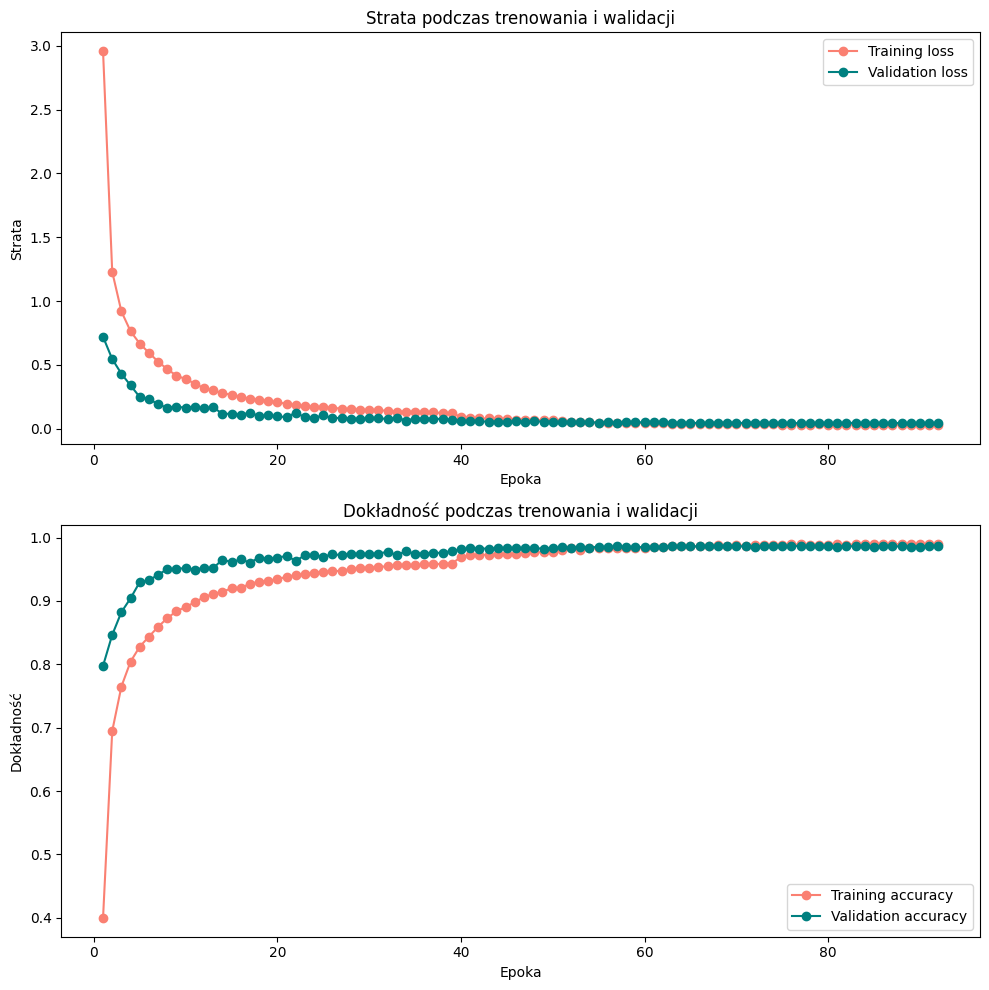

```python
acc = history.history['accuracy']
val_acc = history.history['val_accuracy']
loss = history.history['loss']
val_loss = history.history['val_loss']

epochs = range(1, len(acc) + 1)


plt.figure(figsize=(10, 10))

plt.subplot(2, 1, 1)
plt.plot(epochs, loss, 'o-', label='Training loss', color='salmon')
plt.plot(epochs, val_loss, 'o-', label='Validation loss', color='teal')
plt.title('Strata podczas trenowania i walidacji')
plt.xlabel('Epoka')
plt.ylabel('Strata')
plt.legend()


plt.subplot(2, 1, 2)
plt.plot(epochs, acc, 'o-', label='Training accuracy', color='salmon')
plt.plot(epochs, val_acc, 'o-', label='Validation accuracy', color='teal')
plt.title('Dokładność podczas trenowania i walidacji')
plt.xlabel('Epoka')
plt.ylabel('Dokładność')
plt.legend()

plt.tight_layout()
plt.show()
```

Krzywe znów zaczęły się pokrywać, a ich dynamika nie wskazuje ani na overfitting, ani na underfitting.

```python
y_pred = model.predict(X_test)
y_pred_classes = np.argmax(y_pred, axis=1)
y_test_classes = np.argmax(y_test, axis=1)
```

```
473/473 ━━━━━━━━━━━━━━━━━━━━ 2s 3ms/step
```

```python
accuracy = accuracy_score(y_pred_classes, y_test_classes)
balanced_accuracy = balanced_accuracy_score(y_pred_classes, y_test_classes)
f1 = f1_score(y_pred_classes, y_test_classes, average='macro')
```

```python
print(f"Accuracy: {accuracy:.4f}")
print(f"Balanced Accuracy: {balanced_accuracy:.4f}")
print(f"F1 Score (Macro): {f1:.4f}")
```

```
Accuracy: 0.9868
Balanced Accuracy: 0.9870
F1 Score (Macro): 0.9868
```

Wartości metryk spadły poniżej 99%, więc model jest wyraźnie gorszy od poprzednich.

### Nagrania o długości 1 sekundy.

```python
train_mfcc_list = []
test_mfcc_list = []

train_owner = []
test_owner = []

# W pętli korzystam z wcześniej zdefiniowanej funkcji, która dzieli nagrania każdej z 100 osób
# (50 mężczyzn i 50 kobiet) na zestaw treningowy i testowy.

for i in range(0, 100):

    # Wywołuję funkcję split_train_test_data, aby podzielić nagrania danej osoby na zbiory treningowe i testowe.
    train_mfcc, test_mfcc = split_train_test_data(top_50_man_and_woman[i], seconds = 1)

    # Dodaję uzyskane dane MFCC do odpowiednich list.
    train_mfcc_list.extend(train_mfcc)
    test_mfcc_list.extend(test_mfcc)

    # Do listy train_owner i test_owner dodaję identyfikatory osób (i) tyle razy, ile jest nagrań.
    train_owner.extend([i] * len(train_mfcc))
    test_owner.extend([i] * len(test_mfcc))

    # Wyświetlam numer osoby w pętli, aby śledzić postęp.
    print(i)
    clear_output(wait=True)

# Konwertuję listy train_mfcc_list i test_mfcc_list na tablice NumPy dla łatwiejszego przetwarzania w kolejnych krokach.
train_mfcc_list = np.array(train_mfcc_list)
test_mfcc_list = np.array(test_mfcc_list)

# Konwertuję listy train_owner i test_owner na tablice NumPy.
train_owner = np.array(train_owner)
test_owner = np.array(test_owner)
```

```
99
```

```python
# Łączenie wszystkich macierzy MFCC z zestawu treningowego w jedną dużą macierz.
# To posłuży do dopasowania skalera (normalizatora) do danych.
commmon_df_for_train = np.concatenate(train_mfcc_list, axis=0)

# Inicjalizuję skaler StandardScaler, który będzie normalizował dane (średnia = 0, odchylenie standardowe = 1).
scaler = StandardScaler()

# Dopasowanie skalera do połączonych danych treningowych (uzyskanie parametrów normalizacji).
scaler.fit(commmon_df_for_train)

# Normalizuję dane MFCC dla każdego fragmentu nagrania w zestawie treningowym.
X_train = [scaler.transform(one_audio) for one_audio in train_mfcc_list]

# Normalizuję dane MFCC dla każdego fragmentu nagrania w zestawie testowym.
X_test = [scaler.transform(one_audio) for one_audio in test_mfcc_list]

# Konwertuję znormalizowane dane treningowe i testowe na tablice NumPy w celu łatwiejszego przetwarzania.
X_train = np.array(X_train)
X_test = np.array(X_test)

# Ustalam rozmiar zestawu treningowego - 80% danych.
train_size = int(np.floor(len(X_train) * 0.8))

# Losowy wybór indeksów, które zostaną użyte jako dane treningowe (80% próbek).
index_of_train = np.random.choice(np.arange(0, len(X_train)), size=train_size, replace=False)

# Pozostałe indeksy są używane do walidacji (20% próbek).
index_of_valid = ~np.isin(np.arange(0, len(X_train)), index_of_train)

# Tworzę zbiór walidacyjny z X_train, wybierając próbki z indeksów przypisanych do walidacji.
X_valid = X_train[index_of_valid]

# Ostatecznie, X_train zawiera dane treningowe po wybraniu 80% próbek.
X_train = X_train[index_of_train]

# Przypisuję odpowiednie identyfikatory właścicieli (osób) do zbiorów walidacyjnych i treningowych.
valid_owner = train_owner[index_of_valid]
train_owner = train_owner[index_of_train]
```

```python
# Przekształcam dane treningowe (X_train), aby miały odpowiedni kształt dla sieci CNN.
# Dodaję nowy wymiar (1) na końcu, ponieważ sieci konwolucyjne oczekują wejść o formacie 4D:
# (liczba próbek, wysokość, szerokość, liczba kanałów). Tutaj mamy 1 kanał (monofoniczne nagrania).
X_train = X_train.reshape((X_train.shape[0],
                           X_train.shape[1],
                           X_train.shape[2],
                           1))

# Przekształcam dane walidacyjne (X_valid) do tego samego formatu 4D co dane treningowe.
X_valid = X_valid.reshape((X_valid.shape[0],
                           X_valid.shape[1],
                           X_valid.shape[2],
                           1))

# Przekształcam dane testowe (X_test) w podobny sposób, aby miały wymiar 4D odpowiedni dla sieci CNN.
X_test = X_test.reshape((X_test.shape[0],
                         X_test.shape[1],
                         X_test.shape[2],
                         1))

# Konwertuję etykiety dla zestawu treningowego (train_owner) na postać one-hot encoding dla klasyfikacji wieloklasowej (100 klas).
# Używam funkcji to_categorical, aby zamienić numeryczne etykiety (ID osób) na macierze o rozmiarze [100], gdzie
# każda wartość reprezentuje prawdopodobieństwo przynależności do danej klasy.
y_train = to_categorical(train_owner, num_classes=100)

# Podobnie konwertuję etykiety dla zestawu walidacyjnego na one-hot encoding.
y_valid = to_categorical(valid_owner, num_classes=100)

# Konwersja etykiet dla zestawu testowego na postać one-hot encoding (również 100 klas).
y_test = to_categorical(test_owner, num_classes=100)
```

```python
y_train_labels = np.argmax(y_train, axis=1)

class_counts = np.bincount(y_train_labels)

print(np.min(class_counts), np.max(class_counts))
```

```
935 999
```

```python
# Ustawienie ziarna losowości dla powtarzalnych wyników
np.random.seed(11)
tf.random.set_seed(11)
np.random.seed(11)

# Inicjalizacja modelu
model = models.Sequential()


# Dodanie warstwy wejściowej z kształtem zgodnym z danymi MFCC (157, 13, 1)
model.add(layers.Input(shape=(32, 13, 1)))


# Pierwsza warstwa konwolucyjna, która ma 64 filtry, okno o rozmiarze 3x3, ReLU jako funkcję aktywacji oraz padding 'same'
model.add(layers.Conv2D(32, (3, 3), activation='relu', padding='same'))
# Normalizacja wsadowa dla lepszego uczenia
model.add(layers.BatchNormalization())
# Max Pooling dla zmniejszenia rozmiaru przestrzennego o współczynnik 2
model.add(layers.MaxPooling2D((2, 2)))
# Dropout dla zapobiegania przeuczeniu (wyłącza 10% neuronów losowo)
model.add(layers.Dropout(0.1))


# Druga warstwa konwolucyjna, zwiększamy liczbę filtrów do 128
model.add(layers.Conv2D(64, (3, 3), activation='relu', padding='same'))
model.add(layers.BatchNormalization())
model.add(layers.MaxPooling2D((2, 2)))
model.add(layers.Dropout(0.1))


# Trzecia warstwa konwolucyjna, zwiększamy liczbę filtrów do 256
model.add(layers.Conv2D(128, (3, 3), activation='relu', padding='same'))
model.add(layers.BatchNormalization())
model.add(layers.MaxPooling2D((2, 2)))
model.add(layers.Dropout(0.1))


# Czwarta warstwa konwolucyjna, zwiększamy liczbę filtrów do 512
model.add(layers.Conv2D(256, (3, 3), activation='relu', padding='same'))
model.add(layers.BatchNormalization())
# Dropout dla zapobiegania przeuczeniu (tym razem wyłącza 20% neuronów)
model.add(layers.Dropout(0.2))


# Spłaszczenie wyniku do wektora jednowymiarowego przed przekazaniem go do warstw w pełni połączonych
model.add(layers.Flatten())


# Pierwsza warstwa w pełni połączona (Dense) z 2048 jednostkami, funkcja aktywacji ReLU
model.add(layers.Dense(1024, activation='relu'))
model.add(layers.BatchNormalization())
# Dropout dla zapobiegania przeuczeniu (wyłącza 75% neuronów)
model.add(layers.Dropout(0.75))


# Warstwa wyjściowa - klasyfikacja wieloklasowa z 100 jednostkami i aktywacją softmax (klasyfikacja wieloklasowa)
model.add(layers.Dense(100, activation='softmax'))  # 100 klas (każda klasa reprezentuje innego mówcę)


# Kompilacja modelu - optymalizator Adam, funkcja straty categorical_crossentropy (wieloklasowa klasyfikacja), oraz miara skuteczności - accuracy
model.compile(optimizer='adam',
              loss='categorical_crossentropy',
              metrics=['accuracy'])


# Wyświetlenie podsumowania modelu
model.summary()


# Callbacks: redukcja współczynnika uczenia (learning rate), gdy val_loss przestaje się poprawiać
reduce_lr = ReduceLROnPlateau(monitor='val_loss', factor=0.5, patience=5, min_lr=1e-8)
# Wczesne zatrzymanie treningu, jeśli val_loss nie poprawia się przez 10 epok, przywracając najlepsze wagi
early_stopping = EarlyStopping(monitor='val_loss', patience=15, restore_best_weights=True)


# Trenowanie modelu
history = model.fit(
    X_train,    # Dane MFCC
    y_train,    # Etykiety one-hot encoded (macierz klas mówców)
    epochs=500,  # Liczba epok treningu
    batch_size=16,  # Rozmiar batcha (z dotychczasowych testów wynika, że 32 jest optymalne)
    validation_data=(X_valid, y_valid),  # Walidacja na wcześniej zdefiniowanych danych walidacyjnych
    callbacks=[reduce_lr, early_stopping]  # Callbacki do dynamicznej regulacji uczenia i wczesnego zatrzymania
)
```

```
Model: "sequential_5"
```

```
┏━━━━━━━━━━━━━━━━━━━━━━━━━━━━━━━━━┳━━━━━━━━━━━━━━━━━━━━━━━━┳━━━━━━━━━━━━━━━┓
┃ Layer (type)                    ┃ Output Shape           ┃       Param # ┃
┡━━━━━━━━━━━━━━━━━━━━━━━━━━━━━━━━━╇━━━━━━━━━━━━━━━━━━━━━━━━╇━━━━━━━━━━━━━━━┩
│ conv2d_20 (Conv2D)              │ (None, 32, 13, 32)     │           320 │
├─────────────────────────────────┼────────────────────────┼───────────────┤
│ batch_normalization_25          │ (None, 32, 13, 32)     │           128 │
│ (BatchNormalization)            │                        │               │
├─────────────────────────────────┼────────────────────────┼───────────────┤
│ max_pooling2d_15 (MaxPooling2D) │ (None, 16, 6, 32)      │             0 │
├─────────────────────────────────┼────────────────────────┼───────────────┤
│ dropout_25 (Dropout)            │ (None, 16, 6, 32)      │             0 │
├─────────────────────────────────┼────────────────────────┼───────────────┤
│ conv2d_21 (Conv2D)              │ (None, 16, 6, 64)      │        18,496 │
├─────────────────────────────────┼────────────────────────┼───────────────┤
│ batch_normalization_26          │ (None, 16, 6, 64)      │           256 │
│ (BatchNormalization)            │                        │               │
├─────────────────────────────────┼────────────────────────┼───────────────┤
│ max_pooling2d_16 (MaxPooling2D) │ (None, 8, 3, 64)       │             0 │
├─────────────────────────────────┼────────────────────────┼───────────────┤
│ dropout_26 (Dropout)            │ (None, 8, 3, 64)       │             0 │
├─────────────────────────────────┼────────────────────────┼───────────────┤
│ conv2d_22 (Conv2D)              │ (None, 8, 3, 128)      │        73,856 │
├─────────────────────────────────┼────────────────────────┼───────────────┤
│ batch_normalization_27          │ (None, 8, 3, 128)      │           512 │
│ (BatchNormalization)            │                        │               │
├─────────────────────────────────┼────────────────────────┼───────────────┤
│ max_pooling2d_17 (MaxPooling2D) │ (None, 4, 1, 128)      │             0 │
├─────────────────────────────────┼────────────────────────┼───────────────┤
│ dropout_27 (Dropout)            │ (None, 4, 1, 128)      │             0 │
├─────────────────────────────────┼────────────────────────┼───────────────┤
│ conv2d_23 (Conv2D)              │ (None, 4, 1, 256)      │       295,168 │
├─────────────────────────────────┼────────────────────────┼───────────────┤
│ batch_normalization_28          │ (None, 4, 1, 256)      │         1,024 │
│ (BatchNormalization)            │                        │               │
├─────────────────────────────────┼────────────────────────┼───────────────┤
│ dropout_28 (Dropout)            │ (None, 4, 1, 256)      │             0 │
├─────────────────────────────────┼────────────────────────┼───────────────┤
│ flatten_5 (Flatten)             │ (None, 1024)           │             0 │
├─────────────────────────────────┼────────────────────────┼───────────────┤
│ dense_10 (Dense)                │ (None, 1024)           │     1,049,600 │
├─────────────────────────────────┼────────────────────────┼───────────────┤
│ batch_normalization_29          │ (None, 1024)           │         4,096 │
│ (BatchNormalization)            │                        │               │
├─────────────────────────────────┼────────────────────────┼───────────────┤
│ dropout_29 (Dropout)            │ (None, 1024)           │             0 │
├─────────────────────────────────┼────────────────────────┼───────────────┤
│ dense_11 (Dense)                │ (None, 100)            │       102,500 │
└─────────────────────────────────┴────────────────────────┴───────────────┘
```

```
 Total params: 1,545,956 (5.90 MB)
```

```
 Trainable params: 1,542,948 (5.89 MB)
```

```
 Non-trainable params: 3,008 (11.75 KB)
```

```
6037/6037 ━━━━━━━━━━━━━━━━━━━━ 46s 5ms/step - accuracy: 0.2269 - loss: 3.8930 - val_accuracy: 0.7523 - val_loss: 0.8247 - learning_rate: 0.0010
6037/6037 ━━━━━━━━━━━━━━━━━━━━ 21s 3ms/step - accuracy: 0.6215 - loss: 1.3464 - val_accuracy: 0.8568 - val_loss: 0.4748 - learning_rate: 0.0010
6037/6037 ━━━━━━━━━━━━━━━━━━━━ 21s 3ms/step - accuracy: 0.7195 - loss: 0.9605 - val_accuracy: 0.8963 - val_loss: 0.3332 - learning_rate: 0.0010
6037/6037 ━━━━━━━━━━━━━━━━━━━━ 21s 3ms/step - accuracy: 0.7734 - loss: 0.7630 - val_accuracy: 0.9127 - val_loss: 0.2833 - learning_rate: 0.0010
6037/6037 ━━━━━━━━━━━━━━━━━━━━ 21s 3ms/step - accuracy: 0.8038 - loss: 0.6484 - val_accuracy: 0.9274 - val_loss: 0.2375 - learning_rate: 0.0010
6037/6037 ━━━━━━━━━━━━━━━━━━━━ 21s 3ms/step - accuracy: 0.8307 - loss: 0.5641 - val_accuracy: 0.9302 - val_loss: 0.2272 - learning_rate: 0.0010
6037/6037 ━━━━━━━━━━━━━━━━━━━━ 21s 3ms/step - accuracy: 0.8436 - loss: 0.5103 - val_accuracy: 0.9380 - val_loss: 0.1999 - learning_rate: 0.0010
6037/6037 ━━━━━━━━━━━━━━━━━━━━ 21s 3ms/step - accuracy: 0.8558 - loss: 0.4720 - val_accuracy: 0.9426 - val_loss: 0.1893 - learning_rate: 0.0010
6037/6037 ━━━━━━━━━━━━━━━━━━━━ 21s 3ms/step - accuracy: 0.8643 - loss: 0.4338 - val_accuracy: 0.9423 - val_loss: 0.1878 - learning_rate: 0.0010
6037/6037 ━━━━━━━━━━━━━━━━━━━━ 21s 3ms/step - accuracy: 0.8741 - loss: 0.4062 - val_accuracy: 0.9480 - val_loss: 0.1665 - learning_rate: 0.0010
6037/6037 ━━━━━━━━━━━━━━━━━━━━ 21s 3ms/step - accuracy: 0.8823 - loss: 0.3763 - val_accuracy: 0.9506 - val_loss: 0.1590 - learning_rate: 0.0010
6037/6037 ━━━━━━━━━━━━━━━━━━━━ 21s 3ms/step - accuracy: 0.8863 - loss: 0.3655 - val_accuracy: 0.9507 - val_loss: 0.1550 - learning_rate: 0.0010
6037/6037 ━━━━━━━━━━━━━━━━━━━━ 21s 3ms/step - accuracy: 0.8906 - loss: 0.3521 - val_accuracy: 0.9537 - val_loss: 0.1498 - learning_rate: 0.0010
6037/6037 ━━━━━━━━━━━━━━━━━━━━ 21s 3ms/step - accuracy: 0.8976 - loss: 0.3320 - val_accuracy: 0.9537 - val_loss: 0.1465 - learning_rate: 0.0010
6037/6037 ━━━━━━━━━━━━━━━━━━━━ 21s 3ms/step - accuracy: 0.8980 - loss: 0.3215 - val_accuracy: 0.9565 - val_loss: 0.1417 - learning_rate: 0.0010
6037/6037 ━━━━━━━━━━━━━━━━━━━━ 21s 3ms/step - accuracy: 0.9025 - loss: 0.3017 - val_accuracy: 0.9560 - val_loss: 0.1405 - learning_rate: 0.0010
6037/6037 ━━━━━━━━━━━━━━━━━━━━ 21s 3ms/step - accuracy: 0.9055 - loss: 0.2970 - val_accuracy: 0.9575 - val_loss: 0.1358 - learning_rate: 0.0010
6037/6037 ━━━━━━━━━━━━━━━━━━━━ 21s 3ms/step - accuracy: 0.9077 - loss: 0.2885 - val_accuracy: 0.9577 - val_loss: 0.1381 - learning_rate: 0.0010
6037/6037 ━━━━━━━━━━━━━━━━━━━━ 21s 3ms/step - accuracy: 0.9110 - loss: 0.2819 - val_accuracy: 0.9595 - val_loss: 0.1311 - learning_rate: 0.0010
6037/6037 ━━━━━━━━━━━━━━━━━━━━ 21s 3ms/step - accuracy: 0.9173 - loss: 0.2660 - val_accuracy: 0.9564 - val_loss: 0.1392 - learning_rate: 0.0010
6037/6037 ━━━━━━━━━━━━━━━━━━━━ 21s 3ms/step - accuracy: 0.9169 - loss: 0.2647 - val_accuracy: 0.9613 - val_loss: 0.1299 - learning_rate: 0.0010
6037/6037 ━━━━━━━━━━━━━━━━━━━━ 21s 3ms/step - accuracy: 0.9178 - loss: 0.2581 - val_accuracy: 0.9599 - val_loss: 0.1288 - learning_rate: 0.0010
6037/6037 ━━━━━━━━━━━━━━━━━━━━ 21s 3ms/step - accuracy: 0.9212 - loss: 0.2501 - val_accuracy: 0.9601 - val_loss: 0.1273 - learning_rate: 0.0010
6037/6037 ━━━━━━━━━━━━━━━━━━━━ 21s 3ms/step - accuracy: 0.9209 - loss: 0.2488 - val_accuracy: 0.9613 - val_loss: 0.1303 - learning_rate: 0.0010
6037/6037 ━━━━━━━━━━━━━━━━━━━━ 21s 3ms/step - accuracy: 0.9226 - loss: 0.2431 - val_accuracy: 0.9617 - val_loss: 0.1261 - learning_rate: 0.0010
6037/6037 ━━━━━━━━━━━━━━━━━━━━ 21s 3ms/step - accuracy: 0.9237 - loss: 0.2364 - val_accuracy: 0.9622 - val_loss: 0.1252 - learning_rate: 0.0010
6037/6037 ━━━━━━━━━━━━━━━━━━━━ 20s 3ms/step - accuracy: 0.9258 - loss: 0.2339 - val_accuracy: 0.9624 - val_loss: 0.1255 - learning_rate: 0.0010
6037/6037 ━━━━━━━━━━━━━━━━━━━━ 21s 3ms/step - accuracy: 0.9280 - loss: 0.2282 - val_accuracy: 0.9598 - val_loss: 0.1344 - learning_rate: 0.0010
6037/6037 ━━━━━━━━━━━━━━━━━━━━ 21s 3ms/step - accuracy: 0.9295 - loss: 0.2207 - val_accuracy: 0.9621 - val_loss: 0.1244 - learning_rate: 0.0010
6037/6037 ━━━━━━━━━━━━━━━━━━━━ 21s 3ms/step - accuracy: 0.9306 - loss: 0.2196 - val_accuracy: 0.9621 - val_loss: 0.1239 - learning_rate: 0.0010
6037/6037 ━━━━━━━━━━━━━━━━━━━━ 21s 3ms/step - accuracy: 0.9304 - loss: 0.2178 - val_accuracy: 0.9645 - val_loss: 0.1174 - learning_rate: 0.0010
6037/6037 ━━━━━━━━━━━━━━━━━━━━ 21s 3ms/step - accuracy: 0.9337 - loss: 0.2082 - val_accuracy: 0.9631 - val_loss: 0.1220 - learning_rate: 0.0010
6037/6037 ━━━━━━━━━━━━━━━━━━━━ 21s 3ms/step - accuracy: 0.9343 - loss: 0.2068 - val_accuracy: 0.9641 - val_loss: 0.1170 - learning_rate: 0.0010
6037/6037 ━━━━━━━━━━━━━━━━━━━━ 21s 3ms/step - accuracy: 0.9349 - loss: 0.2048 - val_accuracy: 0.9633 - val_loss: 0.1263 - learning_rate: 0.0010
6037/6037 ━━━━━━━━━━━━━━━━━━━━ 21s 3ms/step - accuracy: 0.9355 - loss: 0.2016 - val_accuracy: 0.9644 - val_loss: 0.1183 - learning_rate: 0.0010
6037/6037 ━━━━━━━━━━━━━━━━━━━━ 21s 3ms/step - accuracy: 0.9348 - loss: 0.2009 - val_accuracy: 0.9618 - val_loss: 0.1259 - learning_rate: 0.0010
6037/6037 ━━━━━━━━━━━━━━━━━━━━ 21s 3ms/step - accuracy: 0.9365 - loss: 0.1974 - val_accuracy: 0.9655 - val_loss: 0.1212 - learning_rate: 0.0010
6037/6037 ━━━━━━━━━━━━━━━━━━━━ 21s 3ms/step - accuracy: 0.9368 - loss: 0.1953 - val_accuracy: 0.9669 - val_loss: 0.1131 - learning_rate: 0.0010
6037/6037 ━━━━━━━━━━━━━━━━━━━━ 21s 3ms/step - accuracy: 0.9369 - loss: 0.1949 - val_accuracy: 0.9656 - val_loss: 0.1167 - learning_rate: 0.0010
6037/6037 ━━━━━━━━━━━━━━━━━━━━ 21s 3ms/step - accuracy: 0.9367 - loss: 0.1942 - val_accuracy: 0.9652 - val_loss: 0.1226 - learning_rate: 0.0010
```

[output cut: 34 more lines]

```
6037/6037 ━━━━━━━━━━━━━━━━━━━━ 21s 3ms/step - accuracy: 0.9760 - loss: 0.0705 - val_accuracy: 0.9744 - val_loss: 0.0921 - learning_rate: 6.2500e-05
6037/6037 ━━━━━━━━━━━━━━━━━━━━ 21s 3ms/step - accuracy: 0.9752 - loss: 0.0725 - val_accuracy: 0.9744 - val_loss: 0.0927 - learning_rate: 6.2500e-05
6037/6037 ━━━━━━━━━━━━━━━━━━━━ 21s 3ms/step - accuracy: 0.9764 - loss: 0.0709 - val_accuracy: 0.9744 - val_loss: 0.0919 - learning_rate: 6.2500e-05
6037/6037 ━━━━━━━━━━━━━━━━━━━━ 21s 3ms/step - accuracy: 0.9754 - loss: 0.0712 - val_accuracy: 0.9745 - val_loss: 0.0908 - learning_rate: 6.2500e-05
6037/6037 ━━━━━━━━━━━━━━━━━━━━ 21s 3ms/step - accuracy: 0.9752 - loss: 0.0718 - val_accuracy: 0.9749 - val_loss: 0.0910 - learning_rate: 6.2500e-05
6037/6037 ━━━━━━━━━━━━━━━━━━━━ 21s 3ms/step - accuracy: 0.9774 - loss: 0.0694 - val_accuracy: 0.9749 - val_loss: 0.0909 - learning_rate: 3.1250e-05
6037/6037 ━━━━━━━━━━━━━━━━━━━━ 21s 3ms/step - accuracy: 0.9778 - loss: 0.0655 - val_accuracy: 0.9746 - val_loss: 0.0918 - learning_rate: 3.1250e-05
6037/6037 ━━━━━━━━━━━━━━━━━━━━ 21s 3ms/step - accuracy: 0.9771 - loss: 0.0670 - val_accuracy: 0.9744 - val_loss: 0.0923 - learning_rate: 3.1250e-05
6037/6037 ━━━━━━━━━━━━━━━━━━━━ 21s 3ms/step - accuracy: 0.9770 - loss: 0.0669 - val_accuracy: 0.9745 - val_loss: 0.0915 - learning_rate: 3.1250e-05
6037/6037 ━━━━━━━━━━━━━━━━━━━━ 21s 3ms/step - accuracy: 0.9747 - loss: 0.0743 - val_accuracy: 0.9747 - val_loss: 0.0922 - learning_rate: 3.1250e-05
6037/6037 ━━━━━━━━━━━━━━━━━━━━ 21s 3ms/step - accuracy: 0.9763 - loss: 0.0679 - val_accuracy: 0.9746 - val_loss: 0.0922 - learning_rate: 1.5625e-05
6037/6037 ━━━━━━━━━━━━━━━━━━━━ 21s 3ms/step - accuracy: 0.9771 - loss: 0.0670 - val_accuracy: 0.9749 - val_loss: 0.0915 - learning_rate: 1.5625e-05
6037/6037 ━━━━━━━━━━━━━━━━━━━━ 21s 3ms/step - accuracy: 0.9763 - loss: 0.0700 - val_accuracy: 0.9747 - val_loss: 0.0916 - learning_rate: 1.5625e-05
6037/6037 ━━━━━━━━━━━━━━━━━━━━ 41s 3ms/step - accuracy: 0.9770 - loss: 0.0692 - val_accuracy: 0.9748 - val_loss: 0.0919 - learning_rate: 1.5625e-05
6037/6037 ━━━━━━━━━━━━━━━━━━━━ 21s 3ms/step - accuracy: 0.9774 - loss: 0.0677 - val_accuracy: 0.9749 - val_loss: 0.0915 - learning_rate: 1.5625e-05
```

Dokładność na zbiorze walidacyjnym spadła poniżej 98%. Model jest wyraźnie gorszy od poprzednich, zwłaszcza tych, które były trenowane na nagraniach o długości 5 sekund.

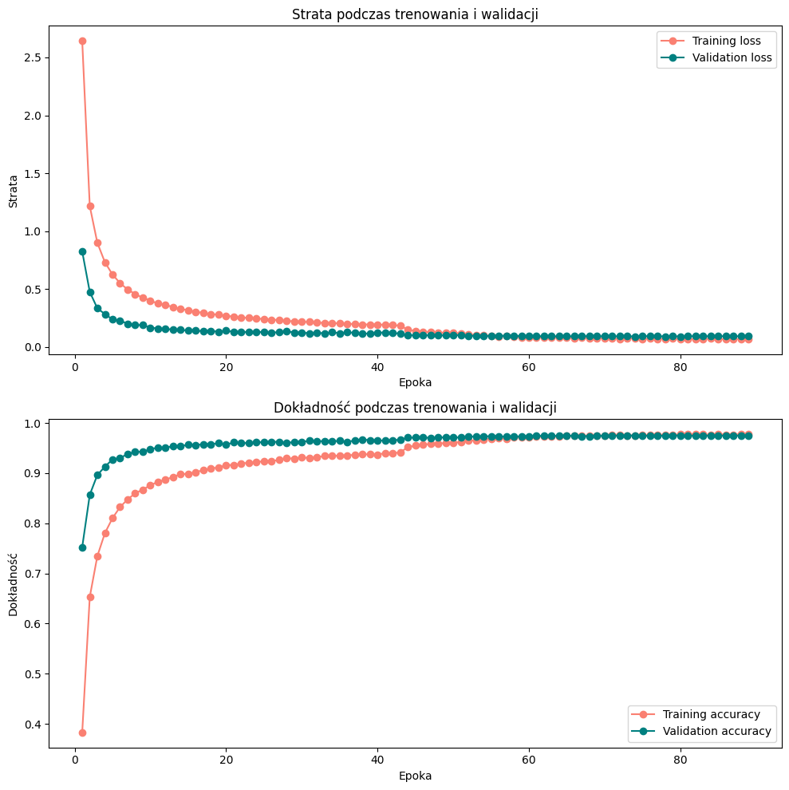

```python
acc = history.history['accuracy']
val_acc = history.history['val_accuracy']
loss = history.history['loss']
val_loss = history.history['val_loss']

epochs = range(1, len(acc) + 1)


plt.figure(figsize=(10, 10))

plt.subplot(2, 1, 1)
plt.plot(epochs, loss, 'o-', label='Training loss', color='salmon')
plt.plot(epochs, val_loss, 'o-', label='Validation loss', color='teal')
plt.title('Strata podczas trenowania i walidacji')
plt.xlabel('Epoka')
plt.ylabel('Strata')
plt.legend()


plt.subplot(2, 1, 2)
plt.plot(epochs, acc, 'o-', label='Training accuracy', color='salmon')
plt.plot(epochs, val_acc, 'o-', label='Validation accuracy', color='teal')
plt.title('Dokładność podczas trenowania i walidacji')
plt.xlabel('Epoka')
plt.ylabel('Dokładność')
plt.legend()

plt.tight_layout()
plt.show()
```

Dynamika krzywych nie wskazuje ani na overfitting, ani na underfitting.

```python
y_pred = model.predict(X_test)
y_pred_classes = np.argmax(y_pred, axis=1)
y_test_classes = np.argmax(y_test, axis=1)
```

```
945/945 ━━━━━━━━━━━━━━━━━━━━ 3s 2ms/step
```

```python
accuracy = accuracy_score(y_pred_classes, y_test_classes)
balanced_accuracy = balanced_accuracy_score(y_pred_classes, y_test_classes)
f1 = f1_score(y_pred_classes, y_test_classes, average='macro')
```

```python
print(f"Accuracy: {accuracy:.4f}")
print(f"Balanced Accuracy: {balanced_accuracy:.4f}")
print(f"F1 Score (Macro): {f1:.4f}")
```

```
Accuracy: 0.9761
Balanced Accuracy: 0.9763
F1 Score (Macro): 0.9761
```

Nie można powiedzieć, że wartości metryk modelu są słabe, ponieważ przekraczają 97%, jednak wskazują, że model jest znacznie gorszy od poprzednich, zwłaszcza tych trenowanych na nagraniach o długości 5 sekund.

#### Model z mniejszą liczbą filtrów w wartwach kownolucyjnych.

```python
# Ustawienie ziarna losowości dla powtarzalnych wyników
np.random.seed(11)
tf.random.set_seed(11)
np.random.seed(11)

# Inicjalizacja modelu
model = models.Sequential()


# Dodanie warstwy wejściowej z kształtem zgodnym z danymi MFCC (157, 13, 1)
model.add(layers.Input(shape=(32, 13, 1)))


# Pierwsza warstwa konwolucyjna, która ma 64 filtry, okno o rozmiarze 3x3, ReLU jako funkcję aktywacji oraz padding 'same'
model.add(layers.Conv2D(16, (3, 3), activation='relu', padding='same'))
# Normalizacja wsadowa dla lepszego uczenia
model.add(layers.BatchNormalization())
# Max Pooling dla zmniejszenia rozmiaru przestrzennego o współczynnik 2
model.add(layers.MaxPooling2D((2, 2)))
# Dropout dla zapobiegania przeuczeniu (wyłącza 10% neuronów losowo)
model.add(layers.Dropout(0.1))


# Druga warstwa konwolucyjna, zwiększamy liczbę filtrów do 128
model.add(layers.Conv2D(32, (3, 3), activation='relu', padding='same'))
model.add(layers.BatchNormalization())
model.add(layers.MaxPooling2D((2, 2)))
model.add(layers.Dropout(0.1))


# Trzecia warstwa konwolucyjna, zwiększamy liczbę filtrów do 256
model.add(layers.Conv2D(64, (3, 3), activation='relu', padding='same'))
model.add(layers.BatchNormalization())
model.add(layers.MaxPooling2D((2, 2)))
model.add(layers.Dropout(0.1))


# Czwarta warstwa konwolucyjna, zwiększamy liczbę filtrów do 512
model.add(layers.Conv2D(128, (3, 3), activation='relu', padding='same'))
model.add(layers.BatchNormalization())
# Dropout dla zapobiegania przeuczeniu (tym razem wyłącza 20% neuronów)
model.add(layers.Dropout(0.2))


# Spłaszczenie wyniku do wektora jednowymiarowego przed przekazaniem go do warstw w pełni połączonych
model.add(layers.Flatten())


# Pierwsza warstwa w pełni połączona (Dense) z 2048 jednostkami, funkcja aktywacji ReLU
model.add(layers.Dense(1024, activation='relu'))
model.add(layers.BatchNormalization())
# Dropout dla zapobiegania przeuczeniu (wyłącza 75% neuronów)
model.add(layers.Dropout(0.75))


# Warstwa wyjściowa - klasyfikacja wieloklasowa z 100 jednostkami i aktywacją softmax (klasyfikacja wieloklasowa)
model.add(layers.Dense(100, activation='softmax'))  # 100 klas (każda klasa reprezentuje innego mówcę)


# Kompilacja modelu - optymalizator Adam, funkcja straty categorical_crossentropy (wieloklasowa klasyfikacja), oraz miara skuteczności - accuracy
model.compile(optimizer='adam',
              loss='categorical_crossentropy',
              metrics=['accuracy'])


# Wyświetlenie podsumowania modelu
model.summary()


# Callbacks: redukcja współczynnika uczenia (learning rate), gdy val_loss przestaje się poprawiać
reduce_lr = ReduceLROnPlateau(monitor='val_loss', factor=0.5, patience=5, min_lr=1e-8)
# Wczesne zatrzymanie treningu, jeśli val_loss nie poprawia się przez 10 epok, przywracając najlepsze wagi
early_stopping = EarlyStopping(monitor='val_loss', patience=15, restore_best_weights=True)


# Trenowanie modelu
history = model.fit(
    X_train,    # Dane MFCC
    y_train,    # Etykiety one-hot encoded (macierz klas mówców)
    epochs=500,  # Liczba epok treningu
    batch_size=16,  # Rozmiar batcha (z dotychczasowych testów wynika, że 32 jest optymalne)
    validation_data=(X_valid, y_valid),  # Walidacja na wcześniej zdefiniowanych danych walidacyjnych
    callbacks=[reduce_lr, early_stopping]  # Callbacki do dynamicznej regulacji uczenia i wczesnego zatrzymania
)
```

```
Model: "sequential_4"
```

```
┏━━━━━━━━━━━━━━━━━━━━━━━━━━━━━━━━━┳━━━━━━━━━━━━━━━━━━━━━━━━┳━━━━━━━━━━━━━━━┓
┃ Layer (type)                    ┃ Output Shape           ┃       Param # ┃
┡━━━━━━━━━━━━━━━━━━━━━━━━━━━━━━━━━╇━━━━━━━━━━━━━━━━━━━━━━━━╇━━━━━━━━━━━━━━━┩
│ conv2d_16 (Conv2D)              │ (None, 32, 13, 16)     │           160 │
├─────────────────────────────────┼────────────────────────┼───────────────┤
│ batch_normalization_20          │ (None, 32, 13, 16)     │            64 │
│ (BatchNormalization)            │                        │               │
├─────────────────────────────────┼────────────────────────┼───────────────┤
│ max_pooling2d_12 (MaxPooling2D) │ (None, 16, 6, 16)      │             0 │
├─────────────────────────────────┼────────────────────────┼───────────────┤
│ dropout_20 (Dropout)            │ (None, 16, 6, 16)      │             0 │
├─────────────────────────────────┼────────────────────────┼───────────────┤
│ conv2d_17 (Conv2D)              │ (None, 16, 6, 32)      │         4,640 │
├─────────────────────────────────┼────────────────────────┼───────────────┤
│ batch_normalization_21          │ (None, 16, 6, 32)      │           128 │
│ (BatchNormalization)            │                        │               │
├─────────────────────────────────┼────────────────────────┼───────────────┤
│ max_pooling2d_13 (MaxPooling2D) │ (None, 8, 3, 32)       │             0 │
├─────────────────────────────────┼────────────────────────┼───────────────┤
│ dropout_21 (Dropout)            │ (None, 8, 3, 32)       │             0 │
├─────────────────────────────────┼────────────────────────┼───────────────┤
│ conv2d_18 (Conv2D)              │ (None, 8, 3, 64)       │        18,496 │
├─────────────────────────────────┼────────────────────────┼───────────────┤
│ batch_normalization_22          │ (None, 8, 3, 64)       │           256 │
│ (BatchNormalization)            │                        │               │
├─────────────────────────────────┼────────────────────────┼───────────────┤
│ max_pooling2d_14 (MaxPooling2D) │ (None, 4, 1, 64)       │             0 │
├─────────────────────────────────┼────────────────────────┼───────────────┤
│ dropout_22 (Dropout)            │ (None, 4, 1, 64)       │             0 │
├─────────────────────────────────┼────────────────────────┼───────────────┤
│ conv2d_19 (Conv2D)              │ (None, 4, 1, 128)      │        73,856 │
├─────────────────────────────────┼────────────────────────┼───────────────┤
│ batch_normalization_23          │ (None, 4, 1, 128)      │           512 │
│ (BatchNormalization)            │                        │               │
├─────────────────────────────────┼────────────────────────┼───────────────┤
│ dropout_23 (Dropout)            │ (None, 4, 1, 128)      │             0 │
├─────────────────────────────────┼────────────────────────┼───────────────┤
│ flatten_4 (Flatten)             │ (None, 512)            │             0 │
├─────────────────────────────────┼────────────────────────┼───────────────┤
│ dense_8 (Dense)                 │ (None, 1024)           │       525,312 │
├─────────────────────────────────┼────────────────────────┼───────────────┤
│ batch_normalization_24          │ (None, 1024)           │         4,096 │
│ (BatchNormalization)            │                        │               │
├─────────────────────────────────┼────────────────────────┼───────────────┤
│ dropout_24 (Dropout)            │ (None, 1024)           │             0 │
├─────────────────────────────────┼────────────────────────┼───────────────┤
│ dense_9 (Dense)                 │ (None, 100)            │       102,500 │
└─────────────────────────────────┴────────────────────────┴───────────────┘
```

```
 Total params: 730,020 (2.78 MB)
```

```
 Trainable params: 727,492 (2.78 MB)
```

```
 Non-trainable params: 2,528 (9.88 KB)
```

```
6037/6037 ━━━━━━━━━━━━━━━━━━━━ 45s 5ms/step - accuracy: 0.1936 - loss: 4.1525 - val_accuracy: 0.7230 - val_loss: 0.9244 - learning_rate: 0.0010
6037/6037 ━━━━━━━━━━━━━━━━━━━━ 19s 3ms/step - accuracy: 0.5474 - loss: 1.6250 - val_accuracy: 0.8222 - val_loss: 0.5929 - learning_rate: 0.0010
6037/6037 ━━━━━━━━━━━━━━━━━━━━ 19s 3ms/step - accuracy: 0.6458 - loss: 1.2271 - val_accuracy: 0.8511 - val_loss: 0.4923 - learning_rate: 0.0010
6037/6037 ━━━━━━━━━━━━━━━━━━━━ 19s 3ms/step - accuracy: 0.6879 - loss: 1.0593 - val_accuracy: 0.8773 - val_loss: 0.4123 - learning_rate: 0.0010
6037/6037 ━━━━━━━━━━━━━━━━━━━━ 19s 3ms/step - accuracy: 0.7191 - loss: 0.9468 - val_accuracy: 0.8863 - val_loss: 0.3687 - learning_rate: 0.0010
6037/6037 ━━━━━━━━━━━━━━━━━━━━ 19s 3ms/step - accuracy: 0.7405 - loss: 0.8829 - val_accuracy: 0.8925 - val_loss: 0.3484 - learning_rate: 0.0010
6037/6037 ━━━━━━━━━━━━━━━━━━━━ 19s 3ms/step - accuracy: 0.7501 - loss: 0.8315 - val_accuracy: 0.9005 - val_loss: 0.3229 - learning_rate: 0.0010
6037/6037 ━━━━━━━━━━━━━━━━━━━━ 20s 3ms/step - accuracy: 0.7613 - loss: 0.7896 - val_accuracy: 0.9040 - val_loss: 0.3050 - learning_rate: 0.0010
6037/6037 ━━━━━━━━━━━━━━━━━━━━ 20s 3ms/step - accuracy: 0.7712 - loss: 0.7680 - val_accuracy: 0.9105 - val_loss: 0.2907 - learning_rate: 0.0010
6037/6037 ━━━━━━━━━━━━━━━━━━━━ 20s 3ms/step - accuracy: 0.7769 - loss: 0.7382 - val_accuracy: 0.9103 - val_loss: 0.2846 - learning_rate: 0.0010
6037/6037 ━━━━━━━━━━━━━━━━━━━━ 19s 3ms/step - accuracy: 0.7832 - loss: 0.7183 - val_accuracy: 0.9187 - val_loss: 0.2616 - learning_rate: 0.0010
6037/6037 ━━━━━━━━━━━━━━━━━━━━ 20s 3ms/step - accuracy: 0.7912 - loss: 0.6871 - val_accuracy: 0.9158 - val_loss: 0.2670 - learning_rate: 0.0010
6037/6037 ━━━━━━━━━━━━━━━━━━━━ 20s 3ms/step - accuracy: 0.7943 - loss: 0.6704 - val_accuracy: 0.9221 - val_loss: 0.2505 - learning_rate: 0.0010
6037/6037 ━━━━━━━━━━━━━━━━━━━━ 20s 3ms/step - accuracy: 0.7997 - loss: 0.6610 - val_accuracy: 0.9223 - val_loss: 0.2502 - learning_rate: 0.0010
6037/6037 ━━━━━━━━━━━━━━━━━━━━ 20s 3ms/step - accuracy: 0.8019 - loss: 0.6554 - val_accuracy: 0.9252 - val_loss: 0.2423 - learning_rate: 0.0010
6037/6037 ━━━━━━━━━━━━━━━━━━━━ 19s 3ms/step - accuracy: 0.8057 - loss: 0.6364 - val_accuracy: 0.9235 - val_loss: 0.2382 - learning_rate: 0.0010
6037/6037 ━━━━━━━━━━━━━━━━━━━━ 20s 3ms/step - accuracy: 0.8096 - loss: 0.6263 - val_accuracy: 0.9260 - val_loss: 0.2328 - learning_rate: 0.0010
6037/6037 ━━━━━━━━━━━━━━━━━━━━ 20s 3ms/step - accuracy: 0.8131 - loss: 0.6111 - val_accuracy: 0.9272 - val_loss: 0.2291 - learning_rate: 0.0010
6037/6037 ━━━━━━━━━━━━━━━━━━━━ 20s 3ms/step - accuracy: 0.8146 - loss: 0.6074 - val_accuracy: 0.9280 - val_loss: 0.2293 - learning_rate: 0.0010
6037/6037 ━━━━━━━━━━━━━━━━━━━━ 20s 3ms/step - accuracy: 0.8146 - loss: 0.6037 - val_accuracy: 0.9282 - val_loss: 0.2252 - learning_rate: 0.0010
6037/6037 ━━━━━━━━━━━━━━━━━━━━ 20s 3ms/step - accuracy: 0.8176 - loss: 0.5969 - val_accuracy: 0.9281 - val_loss: 0.2227 - learning_rate: 0.0010
6037/6037 ━━━━━━━━━━━━━━━━━━━━ 20s 3ms/step - accuracy: 0.8215 - loss: 0.5807 - val_accuracy: 0.9341 - val_loss: 0.2131 - learning_rate: 0.0010
6037/6037 ━━━━━━━━━━━━━━━━━━━━ 20s 3ms/step - accuracy: 0.8227 - loss: 0.5776 - val_accuracy: 0.9330 - val_loss: 0.2145 - learning_rate: 0.0010
6037/6037 ━━━━━━━━━━━━━━━━━━━━ 20s 3ms/step - accuracy: 0.8267 - loss: 0.5663 - val_accuracy: 0.9330 - val_loss: 0.2096 - learning_rate: 0.0010
6037/6037 ━━━━━━━━━━━━━━━━━━━━ 20s 3ms/step - accuracy: 0.8252 - loss: 0.5646 - val_accuracy: 0.9341 - val_loss: 0.2102 - learning_rate: 0.0010
6037/6037 ━━━━━━━━━━━━━━━━━━━━ 20s 3ms/step - accuracy: 0.8286 - loss: 0.5592 - val_accuracy: 0.9335 - val_loss: 0.2095 - learning_rate: 0.0010
6037/6037 ━━━━━━━━━━━━━━━━━━━━ 20s 3ms/step - accuracy: 0.8292 - loss: 0.5547 - val_accuracy: 0.9354 - val_loss: 0.2053 - learning_rate: 0.0010
6037/6037 ━━━━━━━━━━━━━━━━━━━━ 20s 3ms/step - accuracy: 0.8315 - loss: 0.5506 - val_accuracy: 0.9331 - val_loss: 0.2086 - learning_rate: 0.0010
6037/6037 ━━━━━━━━━━━━━━━━━━━━ 20s 3ms/step - accuracy: 0.8304 - loss: 0.5463 - val_accuracy: 0.9369 - val_loss: 0.1998 - learning_rate: 0.0010
6037/6037 ━━━━━━━━━━━━━━━━━━━━ 20s 3ms/step - accuracy: 0.8327 - loss: 0.5426 - val_accuracy: 0.9366 - val_loss: 0.2002 - learning_rate: 0.0010
6037/6037 ━━━━━━━━━━━━━━━━━━━━ 20s 3ms/step - accuracy: 0.8330 - loss: 0.5381 - val_accuracy: 0.9364 - val_loss: 0.2000 - learning_rate: 0.0010
6037/6037 ━━━━━━━━━━━━━━━━━━━━ 19s 3ms/step - accuracy: 0.8350 - loss: 0.5376 - val_accuracy: 0.9376 - val_loss: 0.1971 - learning_rate: 0.0010
6037/6037 ━━━━━━━━━━━━━━━━━━━━ 20s 3ms/step - accuracy: 0.8364 - loss: 0.5293 - val_accuracy: 0.9380 - val_loss: 0.1931 - learning_rate: 0.0010
6037/6037 ━━━━━━━━━━━━━━━━━━━━ 20s 3ms/step - accuracy: 0.8353 - loss: 0.5333 - val_accuracy: 0.9400 - val_loss: 0.1897 - learning_rate: 0.0010
6037/6037 ━━━━━━━━━━━━━━━━━━━━ 20s 3ms/step - accuracy: 0.8387 - loss: 0.5240 - val_accuracy: 0.9381 - val_loss: 0.1961 - learning_rate: 0.0010
6037/6037 ━━━━━━━━━━━━━━━━━━━━ 20s 3ms/step - accuracy: 0.8379 - loss: 0.5240 - val_accuracy: 0.9380 - val_loss: 0.1935 - learning_rate: 0.0010
6037/6037 ━━━━━━━━━━━━━━━━━━━━ 19s 3ms/step - accuracy: 0.8397 - loss: 0.5211 - val_accuracy: 0.9368 - val_loss: 0.1966 - learning_rate: 0.0010
6037/6037 ━━━━━━━━━━━━━━━━━━━━ 20s 3ms/step - accuracy: 0.8400 - loss: 0.5149 - val_accuracy: 0.9366 - val_loss: 0.1985 - learning_rate: 0.0010
6037/6037 ━━━━━━━━━━━━━━━━━━━━ 20s 3ms/step - accuracy: 0.8370 - loss: 0.5132 - val_accuracy: 0.9400 - val_loss: 0.1885 - learning_rate: 0.0010
6037/6037 ━━━━━━━━━━━━━━━━━━━━ 20s 3ms/step - accuracy: 0.8420 - loss: 0.5153 - val_accuracy: 0.9403 - val_loss: 0.1895 - learning_rate: 0.0010
```

[output cut: 93 more lines]

```
6037/6037 ━━━━━━━━━━━━━━━━━━━━ 20s 3ms/step - accuracy: 0.8991 - loss: 0.3146 - val_accuracy: 0.9564 - val_loss: 0.1365 - learning_rate: 1.5625e-05
6037/6037 ━━━━━━━━━━━━━━━━━━━━ 20s 3ms/step - accuracy: 0.8976 - loss: 0.3186 - val_accuracy: 0.9564 - val_loss: 0.1360 - learning_rate: 1.5625e-05
6037/6037 ━━━━━━━━━━━━━━━━━━━━ 19s 3ms/step - accuracy: 0.8951 - loss: 0.3227 - val_accuracy: 0.9563 - val_loss: 0.1360 - learning_rate: 1.5625e-05
6037/6037 ━━━━━━━━━━━━━━━━━━━━ 20s 3ms/step - accuracy: 0.8970 - loss: 0.3224 - val_accuracy: 0.9560 - val_loss: 0.1365 - learning_rate: 1.5625e-05
6037/6037 ━━━━━━━━━━━━━━━━━━━━ 20s 3ms/step - accuracy: 0.8965 - loss: 0.3237 - val_accuracy: 0.9566 - val_loss: 0.1358 - learning_rate: 1.5625e-05
6037/6037 ━━━━━━━━━━━━━━━━━━━━ 19s 3ms/step - accuracy: 0.8964 - loss: 0.3211 - val_accuracy: 0.9563 - val_loss: 0.1365 - learning_rate: 7.8125e-06
6037/6037 ━━━━━━━━━━━━━━━━━━━━ 19s 3ms/step - accuracy: 0.8985 - loss: 0.3143 - val_accuracy: 0.9564 - val_loss: 0.1364 - learning_rate: 7.8125e-06
6037/6037 ━━━━━━━━━━━━━━━━━━━━ 19s 3ms/step - accuracy: 0.8958 - loss: 0.3200 - val_accuracy: 0.9563 - val_loss: 0.1365 - learning_rate: 7.8125e-06
6037/6037 ━━━━━━━━━━━━━━━━━━━━ 20s 3ms/step - accuracy: 0.8972 - loss: 0.3182 - val_accuracy: 0.9564 - val_loss: 0.1363 - learning_rate: 7.8125e-06
6037/6037 ━━━━━━━━━━━━━━━━━━━━ 20s 3ms/step - accuracy: 0.8996 - loss: 0.3160 - val_accuracy: 0.9568 - val_loss: 0.1359 - learning_rate: 7.8125e-06
6037/6037 ━━━━━━━━━━━━━━━━━━━━ 19s 3ms/step - accuracy: 0.8969 - loss: 0.3206 - val_accuracy: 0.9565 - val_loss: 0.1362 - learning_rate: 3.9063e-06
6037/6037 ━━━━━━━━━━━━━━━━━━━━ 20s 3ms/step - accuracy: 0.9000 - loss: 0.3144 - val_accuracy: 0.9566 - val_loss: 0.1364 - learning_rate: 3.9063e-06
6037/6037 ━━━━━━━━━━━━━━━━━━━━ 19s 3ms/step - accuracy: 0.8975 - loss: 0.3191 - val_accuracy: 0.9567 - val_loss: 0.1361 - learning_rate: 3.9063e-06
6037/6037 ━━━━━━━━━━━━━━━━━━━━ 20s 3ms/step - accuracy: 0.8975 - loss: 0.3169 - val_accuracy: 0.9567 - val_loss: 0.1361 - learning_rate: 3.9063e-06
6037/6037 ━━━━━━━━━━━━━━━━━━━━ 19s 3ms/step - accuracy: 0.8976 - loss: 0.3191 - val_accuracy: 0.9566 - val_loss: 0.1362 - learning_rate: 3.9063e-06
```

Model jest słaby – dokładność na zbiorze walidacyjnym wynosi około 95.5%.

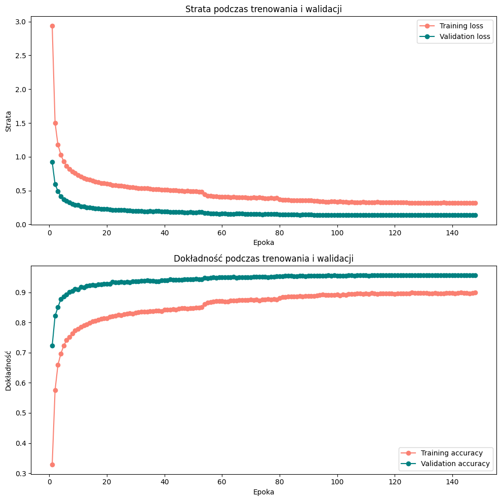

```python
acc = history.history['accuracy']
val_acc = history.history['val_accuracy']
loss = history.history['loss']
val_loss = history.history['val_loss']

epochs = range(1, len(acc) + 1)


plt.figure(figsize=(10, 10))

plt.subplot(2, 1, 1)
plt.plot(epochs, loss, 'o-', label='Training loss', color='salmon')
plt.plot(epochs, val_loss, 'o-', label='Validation loss', color='teal')
plt.title('Strata podczas trenowania i walidacji')
plt.xlabel('Epoka')
plt.ylabel('Strata')
plt.legend()


plt.subplot(2, 1, 2)
plt.plot(epochs, acc, 'o-', label='Training accuracy', color='salmon')
plt.plot(epochs, val_acc, 'o-', label='Validation accuracy', color='teal')
plt.title('Dokładność podczas trenowania i walidacji')
plt.xlabel('Epoka')
plt.ylabel('Dokładność')
plt.legend()

plt.tight_layout()
plt.show()
```

Krzywe uczenia mają ciekawą dynamikę – lepsze wartości metryk uzyskuje zbiór walidacyjny, ale nie świadczy to ani o overfittingu, ani o underfittingu. Overfitting wystąpiłby, gdyby krzywa dla zbioru uczącego osiągała znacznie lepsze metryki niż ta dla zbioru walidacyjnego, natomiast underfitting oznaczałby, że obie krzywe nie osiągają dobrych wyników.

```python
y_pred = model.predict(X_test)
y_pred_classes = np.argmax(y_pred, axis=1)
y_test_classes = np.argmax(y_test, axis=1)
```

```
945/945 ━━━━━━━━━━━━━━━━━━━━ 2s 2ms/step
```

```python
accuracy = accuracy_score(y_pred_classes, y_test_classes)
balanced_accuracy = balanced_accuracy_score(y_pred_classes, y_test_classes)
f1 = f1_score(y_pred_classes, y_test_classes, average='macro')
```

```python
print(f"Accuracy: {accuracy:.4f}")
print(f"Balanced Accuracy: {balanced_accuracy:.4f}")
print(f"F1 Score (Macro): {f1:.4f}")
```

```
Accuracy: 0.9573
Balanced Accuracy: 0.9575
F1 Score (Macro): 0.9571
```

Wartości metryk modelu wypadają blado – nie przekraczają 96%, podczas gdy najlepszy model osiągał niemal 100% we wszystkich metrykach.

# Podsumowanie.

Na jakość modelu wpływa zarówno liczba filtrów w warstwach konwolucyjnych (oczywiście inne parametry modelu CNN również mają znaczenie, jednak w raporcie skupiłem się szczególnie na filtrach w tych warstwach), jak i długość nagrań, na podstawie których uczymy model.  
Najlepiej wypadają modele trenowane na nagraniach o długości 5 sekund oraz te, które mają większą liczbę filtrów w warstwach konwolucyjnych. Zatem najlepszym modelem jest ten, który został opisany jako pierwszy w raporcie – jego dokładność na zbiorach walidacyjnym i testowym wynosi niemal 100%, a krzywe uczenia były niemal wzorowe.